# Исследование объявлений о продаже квартир

## Описание проекта

Данные сервиса Яндекс.Недвижимость — архив объявлений о продаже квартир в Санкт-Петербурге и соседних населённых пунктах за несколько лет.

**Цель исследования** - установить параметры, влияющие на рыночную стоимость объектов недвижимости.

**Задачи данного исследования:**

- изучить параметры объектов;
- выявить аномальные объявления о продаже;
- определить факторы, которые сильнее всего влияют на общую стоимость объектов;
- оценить изменение средней цены объектов в зависимости от местоположения.

**Ход исследования:**

В начале исследования подготовим данные: найдём пропущенные значения в столбцах и заполним их там, где это возможно, изучим уникальные значения в колонках и устраним явные и неявные дубликаты, а также преобразуем некорректные типы данных. Далее приступим к рассмотрению численных и категориальных параметров объектов. При обнаружении редких и выбивающихся значений попробуем определить их природу и восстановить. В основной части исследования попробуем ответить на следующие вопросы:

- Как быстро продавались квартиры в зависимости от количества дней размещения объявлений?
- Как средняя цена объекта зависит от удалённости от центра Санкт-Петербурга?
- Влияет ли общая, жилая площадь, площадь кухни, количество комнат, этаж, дата размещения на цену недвижимости?

В конце опишем полученные результаты и зафиксируем выводы проведённого исследования.

По каждой квартире на продажу доступны два вида данных. Первые вписаны пользователем, вторые — получены автоматически на основе картографических данных. Например, расстояние до центра, аэропорта, ближайшего парка и водоёма.

Результаты исследования позволят построить автоматизированную систему: она сможет отслеживать аномалии и мошенническую деятельность.

## Изучение общей информации

```python
import pandas as pd
import seaborn as sns
import matplotlib.pyplot as plt
import matplotlib
import numpy as np
from matplotlib.ticker import (MultipleLocator, FormatStrFormatter, AutoMinorLocator)
# импорт библиотек pandas, seaborn, matplotlib.pyplot, numpy
from nltk.stem import SnowballStemmer
russian_stemmer = SnowballStemmer('russian')
# импорт из библиотеки NLTK алгоритма SnowballStemmer
%config InlineBackend.figure_format='jpg'
import warnings
warnings.filterwarnings('ignore')
pd.set_option('display.max_columns', None)
```

```python
flats_df = pd.read_csv('/Users/polzovatel/Desktop/Проекты Яндекс доработка/Real estate prices/real_estate_data.csv', sep='\t')
# сохранение файла с данными в переменную flats_df
```

```python
flats_df.head(10)
# получение первых 10 строк таблицы flats_df
```

|  | total_images | last_price | total_area | first_day_exposition | rooms | ceiling_height | floors_total | living_area | floor | is_apartment | studio | open_plan | kitchen_area | balcony | locality_name | airports_nearest | cityCenters_nearest | parks_around3000 | parks_nearest | ponds_around3000 | ponds_nearest | days_exposition |
| --- | --- | --- | --- | --- | --- | --- | --- | --- | --- | --- | --- | --- | --- | --- | --- | --- | --- | --- | --- | --- | --- | --- |
| 0 | 20 | 13000000.0 | 108.00 | 2019-03-07T00:00:00 | 3 | 2.70 | 16.0 | 51.00 | 8 | NaN | False | False | 25.00 | NaN | Санкт-Петербург | 18863.0 | 16028.0 | 1.0 | 482.0 | 2.0 | 755.0 | NaN |
| 1 | 7 | 3350000.0 | 40.40 | 2018-12-04T00:00:00 | 1 | NaN | 11.0 | 18.60 | 1 | NaN | False | False | 11.00 | 2.0 | посёлок Шушары | 12817.0 | 18603.0 | 0.0 | NaN | 0.0 | NaN | 81.0 |
| 2 | 10 | 5196000.0 | 56.00 | 2015-08-20T00:00:00 | 2 | NaN | 5.0 | 34.30 | 4 | NaN | False | False | 8.30 | 0.0 | Санкт-Петербург | 21741.0 | 13933.0 | 1.0 | 90.0 | 2.0 | 574.0 | 558.0 |
| 3 | 0 | 64900000.0 | 159.00 | 2015-07-24T00:00:00 | 3 | NaN | 14.0 | NaN | 9 | NaN | False | False | NaN | 0.0 | Санкт-Петербург | 28098.0 | 6800.0 | 2.0 | 84.0 | 3.0 | 234.0 | 424.0 |
| 4 | 2 | 10000000.0 | 100.00 | 2018-06-19T00:00:00 | 2 | 3.03 | 14.0 | 32.00 | 13 | NaN | False | False | 41.00 | NaN | Санкт-Петербург | 31856.0 | 8098.0 | 2.0 | 112.0 | 1.0 | 48.0 | 121.0 |
| 5 | 10 | 2890000.0 | 30.40 | 2018-09-10T00:00:00 | 1 | NaN | 12.0 | 14.40 | 5 | NaN | False | False | 9.10 | NaN | городской посёлок Янино-1 | NaN | NaN | NaN | NaN | NaN | NaN | 55.0 |
| 6 | 6 | 3700000.0 | 37.30 | 2017-11-02T00:00:00 | 1 | NaN | 26.0 | 10.60 | 6 | NaN | False | False | 14.40 | 1.0 | посёлок Парголово | 52996.0 | 19143.0 | 0.0 | NaN | 0.0 | NaN | 155.0 |
| 7 | 5 | 7915000.0 | 71.60 | 2019-04-18T00:00:00 | 2 | NaN | 24.0 | NaN | 22 | NaN | False | False | 18.90 | 2.0 | Санкт-Петербург | 23982.0 | 11634.0 | 0.0 | NaN | 0.0 | NaN | NaN |
| 8 | 20 | 2900000.0 | 33.16 | 2018-05-23T00:00:00 | 1 | NaN | 27.0 | 15.43 | 26 | NaN | False | False | 8.81 | NaN | посёлок Мурино | NaN | NaN | NaN | NaN | NaN | NaN | 189.0 |
| 9 | 18 | 5400000.0 | 61.00 | 2017-02-26T00:00:00 | 3 | 2.50 | 9.0 | 43.60 | 7 | NaN | False | False | 6.50 | 2.0 | Санкт-Петербург | 50898.0 | 15008.0 | 0.0 | NaN | 0.0 | NaN | 289.0 |

```python
flats_df.info()
# получение общей информации о данных в таблице flats_df
```

```
<class 'pandas.core.frame.DataFrame'>
RangeIndex: 23699 entries, 0 to 23698
Data columns (total 22 columns):
 #   Column                Non-Null Count  Dtype
---  ------                --------------  -----
 0   total_images          23699 non-null  int64
 1   last_price            23699 non-null  float64
 2   total_area            23699 non-null  float64
 3   first_day_exposition  23699 non-null  object
 4   rooms                 23699 non-null  int64
 5   ceiling_height        14504 non-null  float64
 6   floors_total          23613 non-null  float64
 7   living_area           21796 non-null  float64
 8   floor                 23699 non-null  int64
 9   is_apartment          2775 non-null   object
 10  studio                23699 non-null  bool
 11  open_plan             23699 non-null  bool
 12  kitchen_area          21421 non-null  float64
 13  balcony               12180 non-null  float64
 14  locality_name         23650 non-null  object
 15  airports_nearest      18157 non-null  float64
 16  cityCenters_nearest   18180 non-null  float64
 17  parks_around3000      18181 non-null  float64
 18  parks_nearest         8079 non-null   float64
 19  ponds_around3000      18181 non-null  float64
 20  ponds_nearest         9110 non-null   float64
 21  days_exposition       20518 non-null  float64
dtypes: bool(2), float64(14), int64(3), object(3)
memory usage: 3.7+ MB
```

```python
flats_df.describe()
# получение описательной статистики
```

|  | total_images | last_price | total_area | rooms | ceiling_height | floors_total | living_area | floor | kitchen_area | balcony | airports_nearest | cityCenters_nearest | parks_around3000 | parks_nearest | ponds_around3000 | ponds_nearest | days_exposition |
| --- | --- | --- | --- | --- | --- | --- | --- | --- | --- | --- | --- | --- | --- | --- | --- | --- | --- |
| count | 23699.000000 | 2.369900e+04 | 23699.000000 | 23699.000000 | 14504.000000 | 23613.000000 | 21796.000000 | 23699.000000 | 21421.000000 | 12180.000000 | 18157.000000 | 18180.000000 | 18181.000000 | 8079.000000 | 18181.000000 | 9110.000000 | 20518.000000 |
| mean | 9.858475 | 6.541549e+06 | 60.348651 | 2.070636 | 2.771499 | 10.673824 | 34.457852 | 5.892358 | 10.569807 | 1.150082 | 28793.672193 | 14191.277833 | 0.611408 | 490.804555 | 0.770255 | 517.980900 | 180.888634 |
| std | 5.682529 | 1.088701e+07 | 35.654083 | 1.078405 | 1.261056 | 6.597173 | 22.030445 | 4.885249 | 5.905438 | 1.071300 | 12630.880622 | 8608.386210 | 0.802074 | 342.317995 | 0.938346 | 277.720643 | 219.727988 |
| min | 0.000000 | 1.219000e+04 | 12.000000 | 0.000000 | 1.000000 | 1.000000 | 2.000000 | 1.000000 | 1.300000 | 0.000000 | 0.000000 | 181.000000 | 0.000000 | 1.000000 | 0.000000 | 13.000000 | 1.000000 |
| 25% | 6.000000 | 3.400000e+06 | 40.000000 | 1.000000 | 2.520000 | 5.000000 | 18.600000 | 2.000000 | 7.000000 | 0.000000 | 18585.000000 | 9238.000000 | 0.000000 | 288.000000 | 0.000000 | 294.000000 | 45.000000 |
| 50% | 9.000000 | 4.650000e+06 | 52.000000 | 2.000000 | 2.650000 | 9.000000 | 30.000000 | 4.000000 | 9.100000 | 1.000000 | 26726.000000 | 13098.500000 | 0.000000 | 455.000000 | 1.000000 | 502.000000 | 95.000000 |
| 75% | 14.000000 | 6.800000e+06 | 69.900000 | 3.000000 | 2.800000 | 16.000000 | 42.300000 | 8.000000 | 12.000000 | 2.000000 | 37273.000000 | 16293.000000 | 1.000000 | 612.000000 | 1.000000 | 729.000000 | 232.000000 |
| max | 50.000000 | 7.630000e+08 | 900.000000 | 19.000000 | 100.000000 | 60.000000 | 409.700000 | 33.000000 | 112.000000 | 5.000000 | 84869.000000 | 65968.000000 | 3.000000 | 3190.000000 | 3.000000 | 1344.000000 | 1580.000000 |

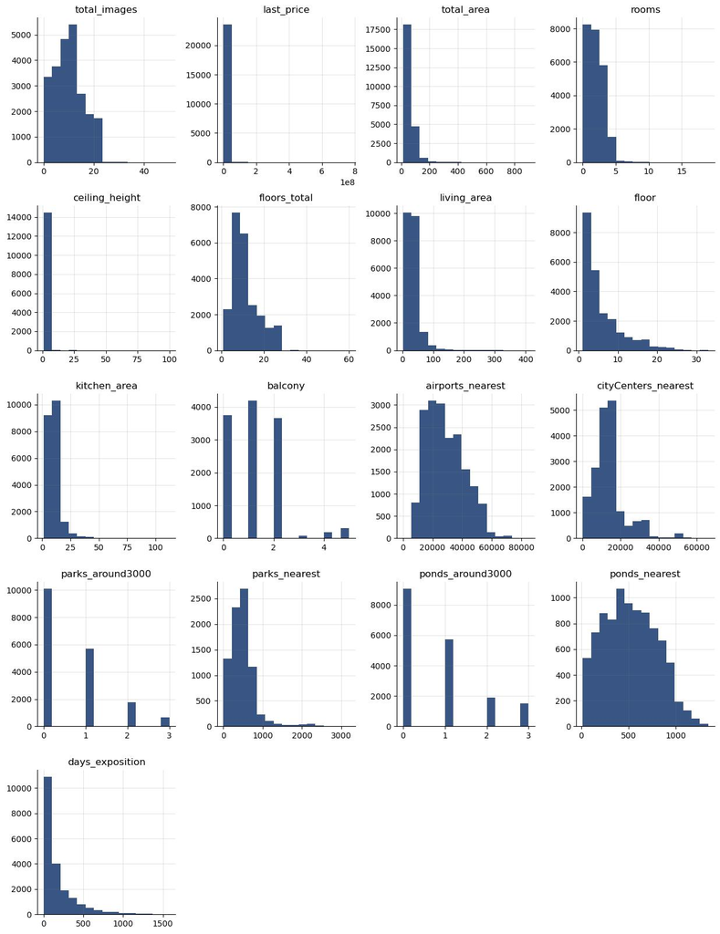

```python
matplotlib.rcParams['axes.spines.right'] = False
matplotlib.rcParams['axes.spines.top'] = False
# удаление линий осей
matplotlib.rcParams['grid.color'] = 'gray'
matplotlib.rcParams['grid.alpha'] = 0.2
# настройка параметров сетки графиков
ax = flats_df.hist(figsize=(15, 20), color='#385583', bins=15)
# вывод гистограмм для всех числовых столбцов таблицы
```

В первую очередь нас интересует целевая переменная - `last_price`. Большинство квартир стоят меньше 7 млн.руб., однако в выборке есть и одиночные выбросы - дорогие объекты стоимостью свыше 50 млн.руб. Объявление о продаже жилья за 12,190 рублей могло быть ошибочно включено в нашу базу данных вместо базы с объявлениями об аренде жилья. Также возможно, что цена квартиры была указана в тысячах рублей.

В столбце `rooms` есть значение 0, что, вероятно, связано с заполнением данных для квартиры-студии или помещения с открытой планировкой, где пользователь мог ошибочно указать 0 вместо 1. Эту гипотезу следует проверить в дальнейшем.

Отметим аномалии в столбце `ceiling_height` в виде значения 100 метров и 1 метр. Такая высота потолков в жилых квартирах, вероятно, не соответствует реальной ситуации на рынке недвижимости.

Квартиры не могут фактически располагаться внутри аэропорта `airports_nearest`, а также находиться на расстоянии всего 1 метра от ближайшего парка `parks_nearest`. Возможно, такие аномалии являются пропусками нестандартного вида или просто ошибками в данных.

### Вывод

Каждая строка таблицы содержит информацию из объявлений о продаже квартир в Санкт-Петербурге и Ленинградской области за несколько лет. Некоторые столбцы предоставляют данные о планировке квартир, такие как общая и жилая площадь, количество комнат, высота потолков, этаж и количество балконов. Другие параметры описывают расположение квартиры, такие как расстояние до центра города, аэропорта, ближайшего парка и водоёма, а также её стоимость на момент снятия объявления с публикации.

Заметно, что в данных присутствуют аномалии, а в большинстве столбцов наблюдаются пропуски. Например, в столбцах `ceiling_height` и `balcony` доля пропущенных значений составляет **39%** и **49%** соответственно.

Необходимо провести очистку датасета от выбросов в столбцах `total_area`, `last_price` и `rooms`. Эти параметры будут использоваться на этапе исследовательского анализа данных для оценки их влияния на стоимость объектов.

## Предобработка данных

```python
flats_df_origin = flats_df.copy()
# копирование датафрейма с "сырыми" данными
```

### Проверка данных на аномалии и исправления

```python
matplotlib.rcParams['font.family'] = 'sans-serif'
# изменение шрифта
def show_distribution(column, title, ylim=[0, 50], number_of_bins=15, range_of_values=(0, 10)):
    fig = plt.figure(figsize=(8, 5))
    ax1 = fig.add_subplot(1, 2, 1)
    ax2 = fig.add_subplot(1, 2, 2)
    # создание сетки из подграфиков
    ax2.yaxis.set_minor_locator(AutoMinorLocator())
    ax2.tick_params(which='minor', length=2, width=1)
    # изменение параметров делений на осях
    ax1.spines['bottom'].set_visible(False)
    ax2.spines['top'].set_visible(False)
    ax2.spines['right'].set_visible(False)
    ax1.xaxis.set_visible(False)
    # удаление линий осей

    fig.suptitle(f'Гистограмма и диаграмма размаха параметра: {title}', fontsize=14)
    # добавление заголовка
    flats_df.boxplot(
                           column,
                           ax=ax1,
                           widths=0.4,
                           showmeans=True,
                           meanline=True,
                           color='#1E2022',
                           flierprops=dict(marker='D', markerfacecolor='white', markeredgecolor='#0D3472', linewidth=1.5),
                           medianprops=dict(linewidth=1.5, color='maroon'),
                           boxprops=dict(linewidth=1.2, color='#1E2022'),
                           meanprops=dict(linewidth=1.5, color='#E32A20')
                          ).set_ylim(ylim)
    flats_df.hist(column, ax=ax2, bins=number_of_bins, range=range_of_values, color='#4A75A5')
    # создание диаграммы размаха и гистограммы
    ax2.set_title(None)

    fig.tight_layout()
    return plt.show()
# создание функции для построения графиков распределения величин: гистограммы и диаграммы размаха
```

#### Цена квартиры

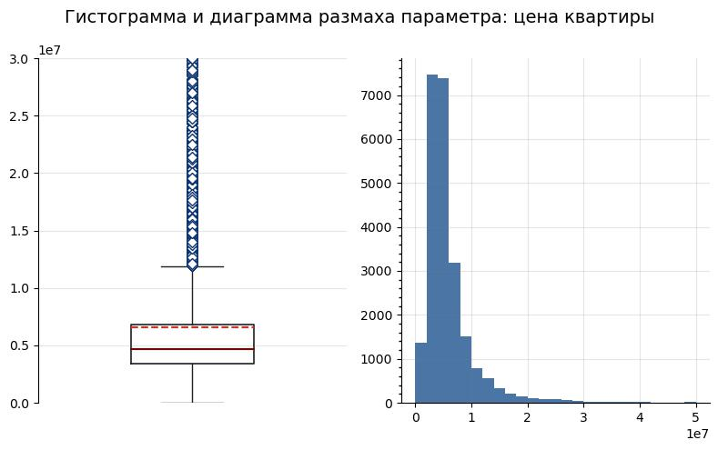

```python
show_distribution('last_price', 'цена квартиры', ylim=[0, 30000000], number_of_bins=25, range_of_values=(0, 50000000))
# вывод графиков распределения цен на квартиры
```

```python
flats_df['last_price'].describe(percentiles=[0.75, 0.90, 0.95, 0.97, 0.99])
# получение описательной статистики для колонки 'last_price'
```

```
count    2.369900e+04
mean     6.541549e+06
std      1.088701e+07
min      1.219000e+04
50%      4.650000e+06
75%      6.800000e+06
90%      1.091423e+07
95%      1.530000e+07
97%      2.000000e+07
99%      3.600000e+07
max      7.630000e+08
Name: last_price, dtype: float64
```

Квартиры с высокой стоимостью, превышающей *50 млн.руб.*, по всей видимости, являются пентхаусами или находятся в историческом центре Санкт-Петербурга в полностью реконструированных старых зданиях.

Для исключения влияния аномальных значений на результаты анализа нужно устранить их.

```python
flats_df = flats_df[flats_df['last_price'] < np.percentile(flats_df['last_price'], 95)]
# удаление аномалий в данных с помощью среза
```

```python
flats_df[flats_df['last_price'] < 400000]
# срез данных
```

|  | total_images | last_price | total_area | first_day_exposition | rooms | ceiling_height | floors_total | living_area | floor | is_apartment | studio | open_plan | kitchen_area | balcony | locality_name | airports_nearest | cityCenters_nearest | parks_around3000 | parks_nearest | ponds_around3000 | ponds_nearest | days_exposition |
| --- | --- | --- | --- | --- | --- | --- | --- | --- | --- | --- | --- | --- | --- | --- | --- | --- | --- | --- | --- | --- | --- | --- |
| 8793 | 7 | 12190.0 | 109.0 | 2019-03-20T00:00:00 | 2 | 2.75 | 25.0 | 32.0 | 25 | NaN | False | False | 40.5 | NaN | Санкт-Петербург | 36421.0 | 9176.0 | 1.0 | 805.0 | 0.0 | NaN | 8.0 |

В таблице представлена всего одна квартира с ценой *12,190 рублей*. Для оценки её приблизительной справедливой стоимости посмотрим аналогичные объявления.

```python
flats_df.query('(30 < living_area < 40) and (rooms == 2) and (100 < total_area < 110) and (locality_name == "Санкт-Петербург") and (7000 < cityCenters_nearest < 11000)')
# срез данных
```

|  | total_images | last_price | total_area | first_day_exposition | rooms | ceiling_height | floors_total | living_area | floor | is_apartment | studio | open_plan | kitchen_area | balcony | locality_name | airports_nearest | cityCenters_nearest | parks_around3000 | parks_nearest | ponds_around3000 | ponds_nearest | days_exposition |
| --- | --- | --- | --- | --- | --- | --- | --- | --- | --- | --- | --- | --- | --- | --- | --- | --- | --- | --- | --- | --- | --- | --- |
| 4031 | 15 | 10700000.0 | 105.4 | 2017-11-10T00:00:00 | 2 | NaN | 10.0 | 30.1 | 4 | NaN | False | False | 13.4 | NaN | Санкт-Петербург | 23562.0 | 7508.0 | 1.0 | 287.0 | 1.0 | 670.0 | 89.0 |
| 8793 | 7 | 12190.0 | 109.0 | 2019-03-20T00:00:00 | 2 | 2.75 | 25.0 | 32.0 | 25 | NaN | False | False | 40.5 | NaN | Санкт-Петербург | 36421.0 | 9176.0 | 1.0 | 805.0 | 0.0 | NaN | 8.0 |

Аналогичное жилье в Санкт-Петербурге оценивается примерно в *11 млн.руб.*, и, вероятно, пользователь просто указал стоимость рассматриваемой квартиры в тысячах рублей.

```python
flats_df.loc[(flats_df['last_price'] < 400000), 'last_price'] = flats_df.loc[8793, 'last_price'] * 1000
# замена значения в столбце на основе условия
```

#### Общая площадь, жилая площадь, площадь кухни

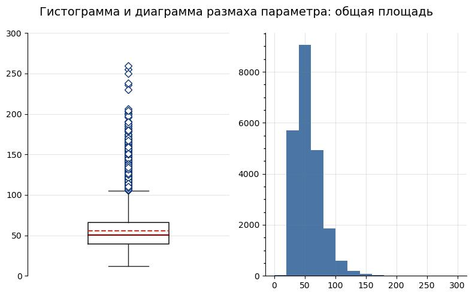

```python
show_distribution('total_area', 'общая площадь', ylim=[0, 300], number_of_bins=15, range_of_values=(0, 300))
# вывод графиков распределения общих площадей
```

```python
flats_df['total_area'].describe(percentiles=[0.75, 0.90, 0.95, 0.97, 0.99])
# получение описательной статистики для колонки 'total_area'
```

```
count    22509.000000
mean        55.248330
std         21.996333
min         12.000000
50%         50.300000
75%         65.900000
90%         83.200000
95%         96.292000
97%        105.200000
99%        126.960000
max        320.000000
Name: total_area, dtype: float64
```

В данных есть отдельные квартиры с площадью более *200 кв.м.* Эти объекты могут представлять собой квартиры, предназначенные для многодетных семей или обеспеченных семей с детьми, а также пентхаусы, включая многоуровневые, охватывающие весь этаж.

```python
flats_df = flats_df[flats_df['total_area'] < np.percentile(flats_df['total_area'], 99)]
# удаление аномалий в данных с помощью среза
```

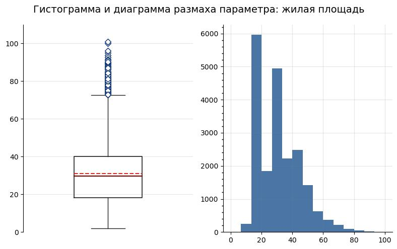

```python
show_distribution('living_area', 'жилая площадь', ylim=[0, 110], number_of_bins=15, range_of_values=(0, 100))
# вывод графиков распределения жилых площадей
```

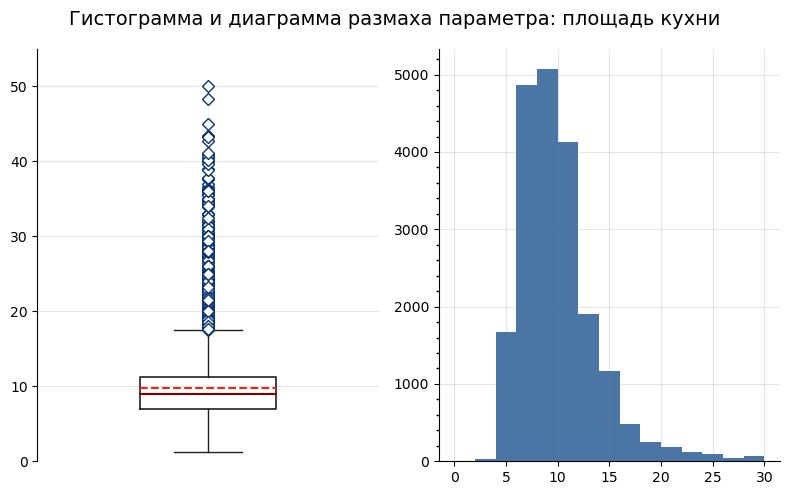

```python
show_distribution('kitchen_area', 'площадь кухни', ylim=[0, 55], number_of_bins=15, range_of_values=(0, 30))
# вывод графиков распределения площадей кухни
```

На гистограмме заметны значения жилой площади *меньше 5 кв.м.* Посмотрим на эти объекты.

```python
flats_df[flats_df['living_area'] < 5]
# срез данных
```

|  | total_images | last_price | total_area | first_day_exposition | rooms | ceiling_height | floors_total | living_area | floor | is_apartment | studio | open_plan | kitchen_area | balcony | locality_name | airports_nearest | cityCenters_nearest | parks_around3000 | parks_nearest | ponds_around3000 | ponds_nearest | days_exposition |
| --- | --- | --- | --- | --- | --- | --- | --- | --- | --- | --- | --- | --- | --- | --- | --- | --- | --- | --- | --- | --- | --- | --- |
| 3242 | 7 | 4440000.0 | 41.0 | 2017-07-02T00:00:00 | 1 | NaN | 17.0 | 3.0 | 17 | NaN | False | False | 11.0 | NaN | Санкт-Петербург | 19272.0 | 13073.0 | 0.0 | NaN | 0.0 | NaN | 216.0 |
| 13915 | 20 | 6350000.0 | 52.0 | 2018-02-06T00:00:00 | 2 | 3.0 | 6.0 | 2.0 | 2 | NaN | False | False | 9.0 | NaN | Санкт-Петербург | 32453.0 | 6521.0 | 0.0 | NaN | 1.0 | 1012.0 | 91.0 |
| 21758 | 0 | 2330000.0 | 23.0 | 2018-01-01T00:00:00 | 0 | NaN | 24.0 | 2.0 | 22 | NaN | True | False | NaN | NaN | посёлок Мурино | NaN | NaN | NaN | NaN | NaN | NaN | 66.0 |

Жилая площадь у данных квартир не может быть меньше общей площади в 15 или 25 раз. Скорее всего это ошибки, возникшие из-за человеческого или технического фактора.

Чтобы заменить некорректные значения, подсчитаем медианное соотношение жилой площади к общей по всем данным.

```python
print(f'Медианное соотношение жилой к общей площади: {round((flats_df["living_area"] / flats_df["total_area"]).median(), 2)}')
```

```
Медианное соотношение жилой к общей площади: 0.57
```

```python
flats_df.loc[(flats_df['living_area'] < 5), 'living_area'] = flats_df.loc[(flats_df['living_area'] < 5), 'living_area'] * 10
# замена значений в столбце на основе условия
```

```python
flats_df.query('(kitchen_area + living_area) > total_area')
# получение среза данных
```

|  | total_images | last_price | total_area | first_day_exposition | rooms | ceiling_height | floors_total | living_area | floor | is_apartment | studio | open_plan | kitchen_area | balcony | locality_name | airports_nearest | cityCenters_nearest | parks_around3000 | parks_nearest | ponds_around3000 | ponds_nearest | days_exposition |
| --- | --- | --- | --- | --- | --- | --- | --- | --- | --- | --- | --- | --- | --- | --- | --- | --- | --- | --- | --- | --- | --- | --- |
| 184 | 7 | 2600000.0 | 30.20 | 2018-02-14T00:00:00 | 1 | 2.65 | 9.0 | 26.10 | 5 | NaN | False | False | 6.20 | NaN | Санкт-Петербург | 13952.0 | 15031.0 | 0.0 | NaN | 1.0 | 824.0 | 12.0 |
| 545 | 9 | 4700000.0 | 23.80 | 2018-12-28T00:00:00 | 1 | NaN | 18.0 | 20.00 | 9 | NaN | False | False | 5.00 | NaN | Санкт-Петербург | 9731.0 | 11849.0 | 0.0 | NaN | 0.0 | NaN | 108.0 |
| 551 | 8 | 3100000.0 | 31.59 | 2018-03-08T00:00:00 | 1 | 2.70 | 19.0 | 30.55 | 2 | NaN | False | False | 9.28 | 2.0 | посёлок Мурино | NaN | NaN | NaN | NaN | NaN | NaN | 70.0 |
| 601 | 12 | 5600000.0 | 53.70 | 2017-04-18T00:00:00 | 2 | 2.50 | 12.0 | 48.30 | 5 | NaN | False | False | 7.00 | 2.0 | Санкт-Петербург | 50477.0 | 13252.0 | 2.0 | 220.0 | 1.0 | 1250.0 | 167.0 |
| 696 | 1 | 3364930.0 | 34.69 | 2014-11-27T00:00:00 | 1 | 2.64 | 25.0 | 23.43 | 25 | NaN | False | False | 23.43 | 2.0 | Санкт-Петербург | 43396.0 | 12153.0 | 0.0 | NaN | 0.0 | NaN | 574.0 |
| ... | ... | ... | ... | ... | ... | ... | ... | ... | ... | ... | ... | ... | ... | ... | ... | ... | ... | ... | ... | ... | ... | ... |
| 21824 | 20 | 2450000.0 | 44.00 | 2019-02-12T00:00:00 | 2 | 27.00 | 2.0 | 38.00 | 2 | False | False | False | 8.60 | 2.0 | городской поселок Большая Ижора | NaN | NaN | NaN | NaN | NaN | NaN | NaN |
| 21868 | 12 | 2600000.0 | 34.30 | 2018-09-26T00:00:00 | 1 | 2.50 | 9.0 | 30.60 | 6 | NaN | False | False | 8.00 | 2.0 | Сосновый Бор | NaN | NaN | NaN | NaN | NaN | NaN | 107.0 |
| 21915 | 14 | 11990000.0 | 91.40 | 2016-05-16T00:00:00 | 2 | NaN | 16.0 | 62.00 | 12 | NaN | False | False | 32.40 | 0.0 | Санкт-Петербург | 10934.0 | 12551.0 | 0.0 | NaN | 0.0 | NaN | 93.0 |
| 21956 | 0 | 5200000.0 | 46.00 | 2018-07-20T00:00:00 | 2 | NaN | 5.0 | 44.00 | 5 | NaN | False | False | 8.00 | 1.0 | Санкт-Петербург | 14103.0 | 15182.0 | 1.0 | 488.0 | 0.0 | NaN | 7.0 |
| 23202 | 13 | 4919880.0 | 67.92 | 2018-10-23T00:00:00 | 2 | NaN | 3.0 | 63.00 | 3 | NaN | False | False | 13.04 | NaN | Всеволожск | NaN | NaN | NaN | NaN | NaN | NaN | 60.0 |

64 rows × 22 columns

В нескольких объявлениях суммарная площадь кухни и жилых помещений превышает общую площадь квартиры. Согласно Жилищному кодексу, общая площадь должна включать все жилые комнаты, санузлы, кухню, кладовку, гардеробную, коридоры, стены и перегородки. Вероятно, на этапе сбора данных произошла некорректная оценка общей площади, либо возникла техническая ошибка. Заменим некорректные значения на сумму жилой площади и площади кухни с целью приблизиться к более точным данным.

```python
flats_df.loc[(flats_df['kitchen_area'] + flats_df['living_area'] > flats_df['total_area']), 'total_area'] = flats_df['kitchen_area'] + flats_df['living_area']
# замена значений в столбце на основе условия
```

#### Число комнат

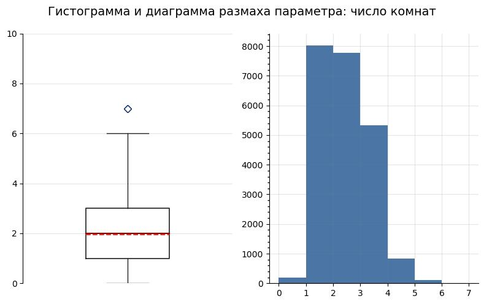

```python
show_distribution('rooms', 'число комнат', ylim=[0, 10], number_of_bins=7, range_of_values=(0, 7))
# вывод графиков распределения числа комнат
```

```python
flats_df[flats_df['rooms'] == 0].describe()
# описательная статистика для среза данных
```

|  | total_images | last_price | total_area | rooms | ceiling_height | floors_total | living_area | floor | kitchen_area | balcony | airports_nearest | cityCenters_nearest | parks_around3000 | parks_nearest | ponds_around3000 | ponds_nearest | days_exposition |
| --- | --- | --- | --- | --- | --- | --- | --- | --- | --- | --- | --- | --- | --- | --- | --- | --- | --- |
| count | 195.000000 | 1.950000e+02 | 195.000000 | 195.0 | 80.00000 | 192.000000 | 182.000000 | 195.000000 | 0.0 | 126.000000 | 116.000000 | 116.000000 | 116.000000 | 28.000000 | 116.000000 | 67.000000 | 181.000000 |
| mean | 7.779487 | 2.924265e+06 | 27.172872 | 0.0 | 3.09850 | 17.010417 | 18.735385 | 8.625641 | NaN | 1.579365 | 24488.879310 | 13517.043103 | 0.293103 | 588.928571 | 0.818966 | 522.970149 | 106.922652 |
| std | 5.098776 | 1.043088e+06 | 6.661562 | 0.0 | 2.73239 | 6.870522 | 5.654635 | 6.302377 | NaN | 0.661552 | 12491.898351 | 4974.277652 | 0.559771 | 306.655426 | 0.880703 | 278.240411 | 156.489136 |
| min | 0.000000 | 9.457500e+05 | 15.500000 | 0.0 | 2.50000 | 3.000000 | 5.000000 | 1.000000 | NaN | 0.000000 | 6989.000000 | 1261.000000 | 0.000000 | 38.000000 | 0.000000 | 72.000000 | 3.000000 |
| 25% | 4.000000 | 2.300000e+06 | 24.025000 | 0.0 | 2.70000 | 12.000000 | 16.000000 | 3.000000 | NaN | 1.000000 | 14247.000000 | 11663.000000 | 0.000000 | 392.750000 | 0.000000 | 342.500000 | 27.000000 |
| 50% | 7.000000 | 2.700000e+06 | 26.000000 | 0.0 | 2.74500 | 17.000000 | 18.000000 | 7.000000 | NaN | 2.000000 | 21131.000000 | 13672.000000 | 0.000000 | 532.000000 | 1.000000 | 527.000000 | 49.000000 |
| 75% | 11.000000 | 3.362500e+06 | 28.250000 | 0.0 | 2.80000 | 23.250000 | 19.975000 | 13.000000 | NaN | 2.000000 | 34201.000000 | 16481.750000 | 0.000000 | 775.750000 | 1.000000 | 687.000000 | 116.000000 |
| max | 21.000000 | 8.200000e+06 | 73.600000 | 0.0 | 27.00000 | 35.000000 | 68.000000 | 26.000000 | NaN | 2.000000 | 55551.000000 | 29846.000000 | 2.000000 | 1199.000000 | 3.000000 | 1159.000000 | 931.000000 |

У квартир без комнат отсутствуют данные о площади кухни. Проверим, можно ли их отнести к студиям либо к квартирам с открытой планировкой.

Студии, как правило, характеризуются наличием единого жилого пространства за исключением санузла, а также отсутствием прихожей и отдельной кухни. В то время как под свободной планировкой подразумевается наличие пространства, ограниченного только несущими стенами, что позволяет изменять планировку.

```python
flats_df[(flats_df['rooms'] == 0) & (flats_df['kitchen_area'].isna())]['rooms'].count()
# подсчёт значений в срезе данных
```

```
195
```

```python
flats_df[(flats_df['rooms'] == 0) & ((flats_df['studio'] == True) | (flats_df['open_plan'] == True))]
# срез данных
```

|  | total_images | last_price | total_area | first_day_exposition | rooms | ceiling_height | floors_total | living_area | floor | is_apartment | studio | open_plan | kitchen_area | balcony | locality_name | airports_nearest | cityCenters_nearest | parks_around3000 | parks_nearest | ponds_around3000 | ponds_nearest | days_exposition |
| --- | --- | --- | --- | --- | --- | --- | --- | --- | --- | --- | --- | --- | --- | --- | --- | --- | --- | --- | --- | --- | --- | --- |
| 144 | 1 | 2450000.0 | 27.00 | 2017-03-30T00:00:00 | 0 | NaN | 24.0 | 15.50 | 2 | NaN | True | False | NaN | 2.0 | посёлок Мурино | NaN | NaN | NaN | NaN | NaN | NaN | 181.0 |
| 349 | 4 | 2320000.0 | 25.00 | 2017-09-27T00:00:00 | 0 | NaN | 14.0 | 17.00 | 1 | NaN | False | True | NaN | 0.0 | деревня Кудрово | NaN | NaN | NaN | NaN | NaN | NaN | 45.0 |
| 440 | 8 | 2480000.0 | 27.11 | 2018-03-12T00:00:00 | 0 | NaN | 17.0 | 24.75 | 4 | NaN | True | False | NaN | 2.0 | Санкт-Петербург | 38171.0 | 15015.0 | 0.0 | NaN | 2.0 | 982.0 | 64.0 |
| 508 | 0 | 3375000.0 | 34.40 | 2017-03-28T00:00:00 | 0 | NaN | 26.0 | 24.30 | 19 | NaN | False | True | NaN | 1.0 | посёлок Парголово | 53115.0 | 19292.0 | 0.0 | NaN | 1.0 | 593.0 | 430.0 |
| 608 | 2 | 1850000.0 | 25.00 | 2019-02-20T00:00:00 | 0 | NaN | 10.0 | NaN | 7 | NaN | True | False | NaN | NaN | посёлок Шушары | NaN | NaN | NaN | NaN | NaN | NaN | 29.0 |
| ... | ... | ... | ... | ... | ... | ... | ... | ... | ... | ... | ... | ... | ... | ... | ... | ... | ... | ... | ... | ... | ... | ... |
| 23210 | 7 | 3200000.0 | 26.00 | 2017-09-01T00:00:00 | 0 | NaN | 25.0 | 18.00 | 16 | NaN | True | False | NaN | 0.0 | Санкт-Петербург | 11405.0 | 13222.0 | 0.0 | NaN | 1.0 | 623.0 | 14.0 |
| 23442 | 0 | 2500000.0 | 27.70 | 2017-09-28T00:00:00 | 0 | NaN | 24.0 | 18.00 | 4 | NaN | False | True | NaN | 2.0 | посёлок Мурино | NaN | NaN | NaN | NaN | NaN | NaN | 4.0 |
| 23554 | 15 | 3350000.0 | 26.00 | 2018-09-07T00:00:00 | 0 | NaN | 19.0 | NaN | 8 | NaN | True | False | NaN | NaN | Санкт-Петербург | 18090.0 | 17092.0 | 0.0 | NaN | 2.0 | 112.0 | 31.0 |
| 23592 | 10 | 1450000.0 | 29.00 | 2017-11-11T00:00:00 | 0 | NaN | 9.0 | 18.00 | 8 | NaN | False | True | NaN | 2.0 | Никольское | NaN | NaN | NaN | NaN | NaN | NaN | 82.0 |
| 23637 | 8 | 2350000.0 | 26.00 | 2018-06-26T00:00:00 | 0 | NaN | 25.0 | 17.00 | 4 | NaN | True | False | NaN | 2.0 | посёлок Бугры | NaN | NaN | NaN | NaN | NaN | NaN | 207.0 |

195 rows × 22 columns

Первоначально выдвинутая гипотеза подтвердилась. Все помещения без комнат - это студии или квартиры с открытой планировкой.

```python
flats_df['rooms'].replace(0, 1, inplace=True)
# замена нулевого числа комнат в столбце 'rooms' на 1
```

#### Высота потолков

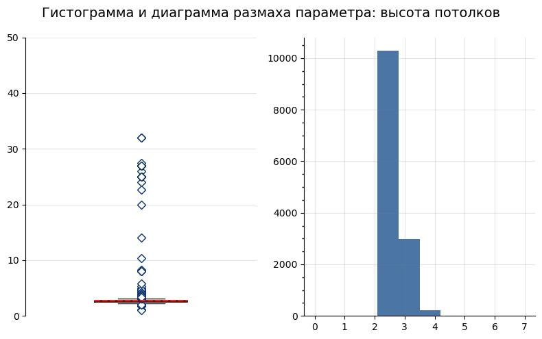

```python
show_distribution('ceiling_height', 'высота потолков', ylim=[0, 50], number_of_bins=10, range_of_values=(0, 7))
# вывод графиков распределения высоты потолков
```

В некоторых квартирах высота потолков значительно превышает медианное значение, а в других - находится ниже отметки в *2 метра*.

```python
flats_df[flats_df['ceiling_height'] < 2]
# срез данных
```

|  | total_images | last_price | total_area | first_day_exposition | rooms | ceiling_height | floors_total | living_area | floor | is_apartment | studio | open_plan | kitchen_area | balcony | locality_name | airports_nearest | cityCenters_nearest | parks_around3000 | parks_nearest | ponds_around3000 | ponds_nearest | days_exposition |
| --- | --- | --- | --- | --- | --- | --- | --- | --- | --- | --- | --- | --- | --- | --- | --- | --- | --- | --- | --- | --- | --- | --- |
| 5712 | 5 | 1500000.0 | 42.8 | 2017-08-14T00:00:00 | 2 | 1.20 | 2.0 | 27.5 | 1 | NaN | False | False | 5.20 | NaN | городской посёлок Мга | NaN | NaN | NaN | NaN | NaN | NaN | 248.0 |
| 16934 | 5 | 4100000.0 | 40.0 | 2017-10-17T00:00:00 | 1 | 1.75 | 37.0 | 17.4 | 5 | NaN | False | False | 8.34 | NaN | Санкт-Петербург | 18732.0 | 20444.0 | 0.0 | NaN | 3.0 | 80.0 | 71.0 |
| 22590 | 16 | 6000000.0 | 55.0 | 2018-10-31T00:00:00 | 2 | 1.00 | 12.0 | 32.4 | 7 | NaN | False | False | 10.00 | NaN | Санкт-Петербург | 33053.0 | 14217.0 | 2.0 | 293.0 | 2.0 | 289.0 | 13.0 |

Квартиры с высотой потолков менее двух метров практически не встречаются в реальных условиях, за исключением случаев, когда они расположены в подвальных помещениях, что маловероятно. Поэтому такие неточные данные можно заменить медианными значениями, учитывая населённый пункт.

```python
flats_df.query('locality_name in ["городской посёлок Мга", "Санкт-Петербург"]').groupby('locality_name')['ceiling_height'].median()
# получение медиан методом группировки groupby
```

```
locality_name
Санкт-Петербург          2.650
городской посёлок Мга    2.515
Name: ceiling_height, dtype: float64
```

```python
flats_df.loc[((flats_df['ceiling_height'] < 2) & (flats_df['locality_name'] == 'городской посёлок Мга')), 'ceiling_height'] = round(flats_df.loc[(flats_df['locality_name'] == 'городской посёлок Мга'), 'ceiling_height'].median(), 2)
flats_df.loc[((flats_df['ceiling_height'] < 2) & (flats_df['locality_name'] == 'Санкт-Петербург')), 'ceiling_height'] = round(flats_df.loc[(flats_df['locality_name'] == 'Санкт-Петербург'), 'ceiling_height'].median(), 2)
# замена значений в столбце на основе условий
```

Новые квартиры с высотой потолков *от 4 до 15 метров* начали появляться среди объявлений за счёт распространённого строительства лофтов, пентхаусов, а также двух и трёхуровневых элитных квартир. Однако такие типы жилья остаются относительно редкими на рынке недвижимости и мы можем рассматривать их скорее как выбросы. Посмотрим на помещения с потолками выше 15 метров.

```python
flats_df[flats_df['ceiling_height'] > 15]
# срез данных
```

|  | total_images | last_price | total_area | first_day_exposition | rooms | ceiling_height | floors_total | living_area | floor | is_apartment | studio | open_plan | kitchen_area | balcony | locality_name | airports_nearest | cityCenters_nearest | parks_around3000 | parks_nearest | ponds_around3000 | ponds_nearest | days_exposition |
| --- | --- | --- | --- | --- | --- | --- | --- | --- | --- | --- | --- | --- | --- | --- | --- | --- | --- | --- | --- | --- | --- | --- |
| 355 | 17 | 3600000.0 | 55.2 | 2018-07-12T00:00:00 | 2 | 25.0 | 5.0 | 32.0 | 2 | False | False | False | NaN | 2.0 | Гатчина | NaN | NaN | NaN | NaN | NaN | NaN | 259.0 |
| 3148 | 14 | 2900000.0 | 75.0 | 2018-11-12T00:00:00 | 3 | 32.0 | 3.0 | 53.0 | 2 | NaN | False | False | 8.0 | NaN | Волхов | NaN | NaN | NaN | NaN | NaN | NaN | NaN |
| 4643 | 0 | 4300000.0 | 45.0 | 2018-02-01T00:00:00 | 2 | 25.0 | 9.0 | 30.0 | 2 | NaN | False | False | 7.0 | 1.0 | Санкт-Петербург | 12016.0 | 13256.0 | 1.0 | 658.0 | 1.0 | 331.0 | 181.0 |
| 4876 | 7 | 3000000.0 | 25.0 | 2017-09-27T00:00:00 | 1 | 27.0 | 25.0 | 17.0 | 17 | NaN | False | True | NaN | 2.0 | посёлок Мурино | NaN | NaN | NaN | NaN | NaN | NaN | 28.0 |
| 5076 | 0 | 3850000.0 | 30.5 | 2018-10-03T00:00:00 | 1 | 24.0 | 5.0 | 19.5 | 1 | True | False | False | 5.5 | NaN | Санкт-Петербург | 29686.0 | 8389.0 | 3.0 | 397.0 | 1.0 | 578.0 | 7.0 |
| 5246 | 0 | 2500000.0 | 54.0 | 2017-10-13T00:00:00 | 2 | 27.0 | 5.0 | 30.0 | 3 | NaN | False | False | 9.0 | 2.0 | деревня Мины | NaN | NaN | NaN | NaN | NaN | NaN | 540.0 |
| 5669 | 4 | 4400000.0 | 50.0 | 2017-08-08T00:00:00 | 2 | 26.0 | 9.0 | 21.3 | 3 | NaN | False | False | 7.0 | 2.0 | Санкт-Петербург | 28981.0 | 10912.0 | 1.0 | 305.0 | 0.0 | NaN | 267.0 |
| 5807 | 17 | 8150000.0 | 80.0 | 2019-01-09T00:00:00 | 2 | 27.0 | 36.0 | 41.0 | 13 | NaN | False | False | 12.0 | 5.0 | Санкт-Петербург | 18732.0 | 20444.0 | 0.0 | NaN | 3.0 | 80.0 | 38.0 |
| 6246 | 6 | 3300000.0 | 44.4 | 2019-03-25T00:00:00 | 2 | 25.0 | 5.0 | 31.3 | 5 | NaN | False | False | 5.7 | NaN | Кронштадт | 68923.0 | 50649.0 | 1.0 | 417.0 | 2.0 | 73.0 | NaN |
| 9379 | 5 | 3950000.0 | 42.0 | 2017-03-26T00:00:00 | 3 | 25.0 | 5.0 | 30.0 | 2 | NaN | False | False | 5.2 | NaN | Санкт-Петербург | 11647.0 | 13581.0 | 0.0 | NaN | 0.0 | NaN | NaN |
| 10773 | 8 | 3800000.0 | 58.0 | 2017-10-13T00:00:00 | 2 | 27.0 | 10.0 | 30.1 | 3 | False | False | False | 8.1 | 2.0 | посёлок Мурино | NaN | NaN | NaN | NaN | NaN | NaN | 71.0 |
| 11285 | 0 | 1950000.0 | 37.0 | 2019-03-20T00:00:00 | 1 | 25.0 | 5.0 | 17.0 | 4 | False | False | False | 9.0 | 2.0 | Луга | NaN | NaN | NaN | NaN | NaN | NaN | 18.0 |
| 14382 | 9 | 1700000.0 | 35.0 | 2015-12-04T00:00:00 | 1 | 25.0 | 5.0 | 20.0 | 2 | False | False | False | 8.0 | 1.0 | поселок Новый Свет | NaN | NaN | NaN | NaN | NaN | NaN | 206.0 |
| 17496 | 15 | 6700000.0 | 92.9 | 2019-02-19T00:00:00 | 3 | 20.0 | 17.0 | 53.2 | 14 | NaN | False | False | 12.0 | 5.0 | Санкт-Петербург | 16295.0 | 15092.0 | 1.0 | 967.0 | 0.0 | NaN | NaN |
| 17857 | 1 | 3900000.0 | 56.0 | 2017-12-22T00:00:00 | 3 | 27.0 | 5.0 | 33.0 | 4 | False | False | False | NaN | NaN | Санкт-Петербург | 41030.0 | 15543.0 | 0.0 | NaN | 0.0 | NaN | 73.0 |
| 18545 | 6 | 3750000.0 | 43.0 | 2019-03-18T00:00:00 | 2 | 25.0 | 5.0 | 29.0 | 3 | False | False | False | NaN | NaN | Санкт-Петербург | 27054.0 | 8033.0 | 1.0 | 540.0 | 0.0 | NaN | 12.0 |
| 20478 | 11 | 8000000.0 | 45.0 | 2017-07-18T00:00:00 | 1 | 27.0 | 4.0 | 22.0 | 2 | NaN | False | False | 10.0 | 1.0 | Санкт-Петербург | 18975.0 | 3246.0 | 0.0 | NaN | 3.0 | 449.0 | 429.0 |
| 20507 | 12 | 5950000.0 | 60.0 | 2018-02-19T00:00:00 | 2 | 22.6 | 14.0 | 35.0 | 11 | NaN | False | False | 13.0 | 1.0 | Санкт-Петербург | 27028.0 | 12570.0 | 0.0 | NaN | 0.0 | NaN | 40.0 |
| 21377 | 19 | 4900000.0 | 48.7 | 2017-04-18T00:00:00 | 1 | 27.5 | 24.0 | 37.7 | 19 | False | False | False | 11.0 | 2.0 | Санкт-Петербург | 42742.0 | 9760.0 | 0.0 | NaN | 0.0 | NaN | 61.0 |
| 21824 | 20 | 2450000.0 | 46.6 | 2019-02-12T00:00:00 | 2 | 27.0 | 2.0 | 38.0 | 2 | False | False | False | 8.6 | 2.0 | городской поселок Большая Ижора | NaN | NaN | NaN | NaN | NaN | NaN | NaN |
| 22336 | 19 | 9999000.0 | 92.4 | 2019-04-05T00:00:00 | 2 | 32.0 | 6.0 | 55.5 | 5 | False | False | False | 16.5 | 4.0 | Санкт-Петербург | 18838.0 | 3506.0 | 0.0 | NaN | 3.0 | 511.0 | NaN |
| 22869 | 0 | 15000000.0 | 25.0 | 2018-07-25T00:00:00 | 1 | 100.0 | 5.0 | 14.0 | 5 | True | False | False | 11.0 | 5.0 | Санкт-Петербург | 34963.0 | 8283.0 | 1.0 | 223.0 | 3.0 | 30.0 | 19.0 |
| 22938 | 14 | 4000000.0 | 98.0 | 2018-03-15T00:00:00 | 4 | 27.0 | 2.0 | 73.0 | 2 | True | False | False | 9.0 | 1.0 | деревня Нижняя | NaN | NaN | NaN | NaN | NaN | NaN | 27.0 |

В срезе данных выделяется объявление о продаже квартиры с потолком высотой *100 метров*. Однако, судя по другим характеристикам этой квартиры, таким как стоимость (15 млн. руб.), жилая площадь (14 кв.м.) и количество балконов (5), данное объявление можно рассматривать как аномалию, которую лучше удалить из датафрейма.

Также в данном срезе присутствует множество квартир с потолками *выше 20 метров*. Вероятно, эти данные были введены вручную с ошибкой в разделителе (например, 25 метров вместо 2.5 метров).

```python
flats_df = flats_df[flats_df['ceiling_height'] != 100]
# удаление строки
```

```python
flats_df.loc[(flats_df['ceiling_height'] > 15), 'ceiling_height'] = flats_df['ceiling_height'] / 10
# замена значений в столбце
```

#### Расстояние до ближайшего аэропорта и парка

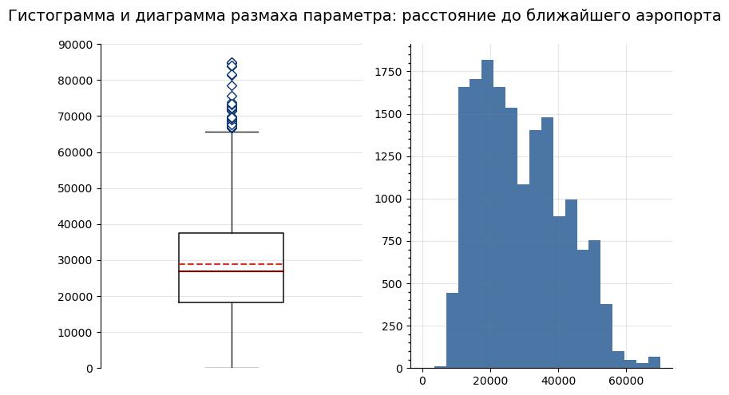

```python
show_distribution('airports_nearest', 'расстояние до ближайшего аэропорта', ylim=[0, 90000], number_of_bins=20, range_of_values=(0, 70000))
# вывод графиков распределения расстояний до ближайшего аэропорта
```

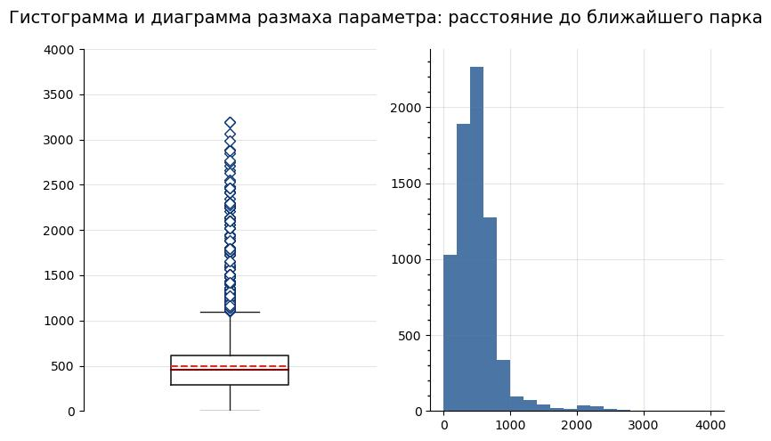

```python
show_distribution('parks_nearest', 'расстояние до ближайшего парка', ylim=[0, 4000], number_of_bins=20, range_of_values=(0, 4000))
# вывод графиков распределения расстояний до ближайшего парка
```

```python
flats_df[flats_df['airports_nearest'] < 500]
# срез данных
```

|  | total_images | last_price | total_area | first_day_exposition | rooms | ceiling_height | floors_total | living_area | floor | is_apartment | studio | open_plan | kitchen_area | balcony | locality_name | airports_nearest | cityCenters_nearest | parks_around3000 | parks_nearest | ponds_around3000 | ponds_nearest | days_exposition |
| --- | --- | --- | --- | --- | --- | --- | --- | --- | --- | --- | --- | --- | --- | --- | --- | --- | --- | --- | --- | --- | --- | --- |
| 21085 | 0 | 7000000.0 | 34.7 | 2018-09-23T00:00:00 | 1 | 2.7 | 9.0 | 19.8 | 3 | NaN | False | False | 6.0 | 2.0 | Санкт-Петербург | 0.0 | 22801.0 | 0.0 | NaN | 0.0 | NaN | 60.0 |

Судя по всему, нулевое расстояние до аэропорта в данном объявлении - это пропуск в данных, потому как в нём также отсутствуют расстояния в колонках `parks_nearest` и `ponds_nearest`. Пропущенное значение заменим на NaN.

```python
flats_df.loc[(flats_df['airports_nearest'] < 500), 'airports_nearest'] = np.nan
# замена значений в столбце
```

Ограничим минимальное расстояние до парка десятью метрами, в том случае если парк находится через дорогу или по соседству от жилого дома.

```python
flats_df[flats_df['parks_nearest'] < 10]
# срез данных
```

|  | total_images | last_price | total_area | first_day_exposition | rooms | ceiling_height | floors_total | living_area | floor | is_apartment | studio | open_plan | kitchen_area | balcony | locality_name | airports_nearest | cityCenters_nearest | parks_around3000 | parks_nearest | ponds_around3000 | ponds_nearest | days_exposition |
| --- | --- | --- | --- | --- | --- | --- | --- | --- | --- | --- | --- | --- | --- | --- | --- | --- | --- | --- | --- | --- | --- | --- |
| 2527 | 8 | 4690000.0 | 60.3 | 2016-03-05T00:00:00 | 2 | 2.5 | 5.0 | 28.00 | 2 | NaN | False | False | 7.9 | 0.0 | Кронштадт | 69775.0 | 51500.0 | 3.0 | 9.0 | 3.0 | 345.0 | 146.0 |
| 9344 | 12 | 3000000.0 | 28.1 | 2017-07-25T00:00:00 | 1 | 2.5 | 9.0 | 17.00 | 1 | NaN | False | False | 5.6 | NaN | Санкт-Петербург | 12051.0 | 11665.0 | 1.0 | 7.0 | 1.0 | 780.0 | 440.0 |
| 11949 | 7 | 4500000.0 | 44.0 | 2017-11-24T00:00:00 | 2 | 2.6 | 9.0 | 30.00 | 7 | NaN | False | False | 7.0 | NaN | Санкт-Петербург | 11806.0 | 12292.0 | 1.0 | 3.0 | 1.0 | 508.0 | 82.0 |
| 14624 | 8 | 3770000.0 | 45.4 | 2019-03-20T00:00:00 | 2 | NaN | 9.0 | 28.43 | 2 | NaN | False | False | 6.9 | NaN | Санкт-Петербург | 43932.0 | 16436.0 | 1.0 | 1.0 | 0.0 | NaN | 42.0 |
| 20193 | 3 | 11809670.0 | 102.6 | 2017-04-21T00:00:00 | 3 | NaN | 9.0 | NaN | 3 | False | False | False | 17.8 | 2.0 | Санкт-Петербург | 27562.0 | 6410.0 | 2.0 | 9.0 | 2.0 | 480.0 | 90.0 |
| 22941 | 8 | 10965000.0 | 69.3 | 2019-01-10T00:00:00 | 1 | 3.0 | 4.0 | 48.90 | 4 | True | False | False | NaN | 2.0 | Зеленогорск | 73391.0 | 54490.0 | 3.0 | 4.0 | 1.0 | 217.0 | 110.0 |

Ошибочные значения можно заменить на медианное расстояние до парка, чтобы аномалии в данных впоследствии не смещали выборку.

```python
flats_df.loc[(flats_df['parks_nearest'] < 10), 'parks_nearest'] = flats_df['parks_nearest'].median()
# замена значений в столбце
```

Далее проверим внесённые изменения.

```python
flats_df.describe()
# получение описательной статистики
```

|  | total_images | last_price | total_area | rooms | ceiling_height | floors_total | living_area | floor | kitchen_area | balcony | airports_nearest | cityCenters_nearest | parks_around3000 | parks_nearest | ponds_around3000 | ponds_nearest | days_exposition |
| --- | --- | --- | --- | --- | --- | --- | --- | --- | --- | --- | --- | --- | --- | --- | --- | --- | --- |
| count | 22282.000000 | 2.228200e+04 | 22282.000000 | 22282.000000 | 13545.000000 | 22202.000000 | 20538.000000 | 22282.000000 | 20144.000000 | 11551.000000 | 16783.000000 | 16799.000000 | 16800.000000 | 7127.000000 | 16800.000000 | 8154.000000 | 19494.000000 |
| mean | 9.739027 | 5.097580e+06 | 54.285547 | 1.962346 | 2.699441 | 10.794928 | 31.094562 | 5.911363 | 9.815119 | 1.147087 | 28886.151165 | 14735.965653 | 0.570298 | 493.008419 | 0.725060 | 528.237429 | 175.056069 |
| std | 5.586099 | 2.636230e+06 | 19.627621 | 0.900743 | 0.283422 | 6.649904 | 13.727827 | 4.918509 | 4.141900 | 1.053179 | 12891.631414 | 8521.986173 | 0.771809 | 336.099658 | 0.905271 | 277.087789 | 213.677551 |
| min | 0.000000 | 4.300000e+05 | 12.000000 | 1.000000 | 2.000000 | 1.000000 | 5.000000 | 1.000000 | 1.300000 | 0.000000 | 6450.000000 | 208.000000 | 0.000000 | 10.000000 | 0.000000 | 13.000000 | 1.000000 |
| 25% | 6.000000 | 3.350000e+06 | 39.300000 | 1.000000 | 2.500000 | 5.000000 | 18.200000 | 2.000000 | 7.000000 | 0.000000 | 18231.500000 | 10326.000000 | 0.000000 | 292.500000 | 0.000000 | 311.000000 | 44.000000 |
| 50% | 9.000000 | 4.500000e+06 | 50.000000 | 2.000000 | 2.600000 | 9.000000 | 29.700000 | 4.000000 | 9.000000 | 1.000000 | 26971.000000 | 13445.000000 | 0.000000 | 457.000000 | 0.000000 | 515.000000 | 92.000000 |
| 75% | 14.000000 | 6.200000e+06 | 65.000000 | 3.000000 | 2.760000 | 16.000000 | 40.000000 | 8.000000 | 11.200000 | 2.000000 | 37499.000000 | 16581.000000 | 1.000000 | 614.500000 | 1.000000 | 738.000000 | 222.000000 |
| max | 50.000000 | 1.520000e+07 | 126.500000 | 7.000000 | 14.000000 | 60.000000 | 101.000000 | 33.000000 | 64.000000 | 5.000000 | 84869.000000 | 65968.000000 | 3.000000 | 3190.000000 | 3.000000 | 1344.000000 | 1580.000000 |

```python
print('В результате удаления аномалий осталось {:.0%} от первоначальных данных'.format(flats_df.shape[0] / flats_df_origin.shape[0]))
```

```
В результате удаления аномалий осталось 94% от первоначальных данных
```

### Удаление дубликатов

```python
print(flats_df.duplicated().sum())
# подсчёт явных дубликатов
```

```
0
```

Явных дубликатов нет.

```python
flats_df.describe(include=['object', 'bool'])
# получение описательной статистики для категориальных переменных
```

|  | first_day_exposition | is_apartment | studio | open_plan | locality_name |
| --- | --- | --- | --- | --- | --- |
| count | 22282 | 2595 | 22282 | 22282 | 22237 |
| unique | 1483 | 2 | 2 | 2 | 363 |
| top | 2018-02-01T00:00:00 | False | False | False | Санкт-Петербург |
| freq | 349 | 2554 | 22134 | 22217 | 14382 |

```python
flats_df['locality_name'].unique()
# просмотр уникальных наименований населённых пунктов
```

```
array(['Санкт-Петербург', 'посёлок Шушары', 'городской посёлок Янино-1',
       'посёлок Парголово', 'посёлок Мурино', 'Ломоносов', 'Сертолово',
       'Петергоф', 'Пушкин', 'деревня Кудрово', 'Коммунар', 'Колпино',
       'поселок городского типа Красный Бор', 'Гатчина', 'поселок Мурино',
       'деревня Фёдоровское', 'Выборг', 'Кронштадт', 'Кировск',
       'деревня Новое Девяткино', 'посёлок Металлострой',
       'посёлок городского типа Лебяжье',
       'посёлок городского типа Сиверский', 'поселок Молодцово',
       'поселок городского типа Кузьмоловский',
       'садовое товарищество Новая Ропша', 'Павловск',
       'деревня Пикколово', 'Всеволожск', 'Волхов', 'Кингисепп',
       'Приозерск', 'Сестрорецк', 'деревня Куттузи', 'посёлок Аннино',
       'поселок городского типа Ефимовский', 'посёлок Плодовое',
       'деревня Заклинье', 'поселок Торковичи', 'поселок Первомайское',
       'Красное Село', 'посёлок Понтонный', 'Сясьстрой', 'деревня Старая',
       'деревня Лесколово', 'посёлок Новый Свет', 'Сланцы',
       'село Путилово', 'Ивангород', 'Мурино', 'Шлиссельбург',
       'Никольское', 'Зеленогорск', 'Сосновый Бор', 'поселок Новый Свет',
       'деревня Оржицы', 'деревня Кальтино', 'Кудрово',
       'поселок Романовка', 'посёлок Бугры', 'поселок Бугры',
       'поселок городского типа Рощино', 'Кириши', 'Луга', 'Волосово',
       'Отрадное', 'село Павлово', 'поселок Оредеж', 'село Копорье',
       'посёлок городского типа Красный Бор', 'посёлок Молодёжное',
       'Тихвин', 'посёлок Победа', 'деревня Нурма',
       'поселок городского типа Синявино', 'Тосно',
       'посёлок городского типа Кузьмоловский', 'посёлок Стрельна',
       'Бокситогорск', 'деревня Лопухинка', 'Пикалёво',
       'поселок Терволово', 'поселок городского типа Советский',
       'Подпорожье', 'посёлок Петровское',
       'посёлок городского типа Токсово', 'поселок Сельцо',
       'посёлок городского типа Вырица', 'деревня Кипень',
       'деревня Келози', 'деревня Вартемяги', 'посёлок Тельмана',
       'поселок Севастьяново', 'городской поселок Большая Ижора', nan,
       'городской посёлок Павлово', 'деревня Агалатово',
       'посёлок Новогорелово', 'городской посёлок Лесогорский',
       'деревня Лаголово', 'поселок Цвелодубово',
       'поселок городского типа Рахья', 'поселок городского типа Вырица',
       'деревня Белогорка', 'поселок Заводской',
       'городской посёлок Новоселье', 'деревня Большие Колпаны',
       'деревня Горбунки', 'деревня Батово', 'деревня Заневка',
```

[output cut: 91 more lines]

```
       'посёлок Шугозеро', 'деревня Ваганово', 'поселок Пушное',
       'садовое товарищество Садко', 'посёлок Усть-Ижора',
       'деревня Выскатка', 'городской посёлок Свирьстрой',
       'поселок Громово', 'деревня Кисельня', 'посёлок Старая Малукса',
       'деревня Трубников Бор', 'поселок Калитино',
       'посёлок Высокоключевой', 'садовое товарищество Приладожский',
       'посёлок Пансионат Зелёный Бор', 'деревня Ненимяки',
       'поселок Пансионат Зелёный Бор', 'деревня Снегирёвка',
       'посёлок Александровская', 'деревня Рапполово', 'деревня Пустынка',
       'поселок Рабитицы', 'деревня Большой Сабск', 'деревня Русско',
       'деревня Лупполово', 'деревня Большое Рейзино',
       'деревня Малая Романовка', 'поселок Дружноселье', 'поселок Пчевжа',
       'поселок Володарское', 'деревня Нижняя',
       'коттеджный посёлок Лесное', 'деревня Тихковицы',
       'деревня Борисова Грива', 'посёлок Дзержинского'], dtype=object)
```

```python
len(flats_df['locality_name'].unique())
# число уникальных названий населённых пунктов
```

```
364
```

Среди названий населённых пунктов присутствуют неявные дубликаты. Например, 'поселок Перово' и 'посёлок Перово', а также 'село Павлово', 'городской посёлок Павлово' и 'посёлок городского типа Павлово' - обозначения одних и тех же населённых пунктов.

Заполним пустые значения в столбце `locality_name` строкой 'unknown'.

```python
flats_df['locality_name'].fillna('unknown', inplace=True)
# заполнение пропущенных значений
```

```python
flats_df['locality_name'] = flats_df['locality_name'].apply(lambda x: x.replace('ё', 'е'))
# замена буквы в наименованиях населённых пунктов
```

```python
list_to_replace = ['городской поселок',
                   'поселок городского типа',
                   'поселок станции',
                   'поселок при железнодорожной станции',
                   'коттеджный поселок',
                   'село ',
                   'садовое товарищество',
                   'садоводческое некоммерческое товарищество',
                   'деревня',
                   'поселок']
for locality in list_to_replace:
    flats_df['locality_name'] = flats_df['locality_name'].apply(lambda x: x.replace(locality, ''))
# замена неявных дубликатов
```

```python
flats_df['locality_name'] = flats_df['locality_name'].apply(lambda x: x.strip())
# удаление начальных символов в наименованиях населённых пунктов
```

```python
flats_df['locality_name'].unique()
# просмотр уникальных наименований населённых пунктов после удаления неявных дубликатов
```

```
array(['Санкт-Петербург', 'Шушары', 'Янино-1', 'Парголово', 'Мурино',
       'Ломоносов', 'Сертолово', 'Петергоф', 'Пушкин', 'Кудрово',
       'Коммунар', 'Колпино', 'Красный Бор', 'Гатчина', 'Федоровское',
       'Выборг', 'Кронштадт', 'Кировск', 'Новое Девяткино',
       'Металлострой', 'Лебяжье', 'Сиверский', 'Молодцово',
       'Кузьмоловский', 'Новая Ропша', 'Павловск', 'Пикколово',
       'Всеволожск', 'Волхов', 'Кингисепп', 'Приозерск', 'Сестрорецк',
       'Куттузи', 'Аннино', 'Ефимовский', 'Плодовое', 'Заклинье',
       'Торковичи', 'Первомайское', 'Красное Село', 'Понтонный',
       'Сясьстрой', 'Старая', 'Лесколово', 'Новый Свет', 'Сланцы',
       'Путилово', 'Ивангород', 'Шлиссельбург', 'Никольское',
       'Зеленогорск', 'Сосновый Бор', 'Оржицы', 'Кальтино', 'Романовка',
       'Бугры', 'Рощино', 'Кириши', 'Луга', 'Волосово', 'Отрадное',
       'Павлово', 'Оредеж', 'Копорье', 'Молодежное', 'Тихвин', 'Победа',
       'Нурма', 'Синявино', 'Тосно', 'Стрельна', 'Бокситогорск',
       'Лопухинка', 'Пикалево', 'Терволово', 'Советский', 'Подпорожье',
       'Петровское', 'Токсово', 'Сельцо', 'Вырица', 'Кипень', 'Келози',
       'Вартемяги', 'Тельмана', 'Севастьяново', 'Большая Ижора',
       'unknown', 'Агалатово', 'Новогорелово', 'Лесогорский', 'Лаголово',
       'Цвелодубово', 'Рахья', 'Белогорка', 'Заводской', 'Новоселье',
       'Большие Колпаны', 'Горбунки', 'Батово', 'Заневка', 'Иссад',
       'Приморск', 'Мистолово', 'Новая Ладога', 'Зимитицы', 'Барышево',
       'Разметелево', 'имени Свердлова', 'Пеники', 'Рябово', 'Пудомяги',
       'Корнево', 'Низино', 'Бегуницы', 'Поляны', 'Мга', 'Елизаветино',
       'Кузнечное', 'Колтуши', 'Запорожское', 'Гостилицы',
       'Малое Карлино', 'Мичуринское', 'имени Морозова', 'Песочный',
       'Сосново', 'Аро', 'Ильичево', 'Тайцы', 'Малое Верево', 'Извара',
       'Вещево', 'Паша', 'Калитино', 'Ульяновка', 'Чудской Бор',
       'Дубровка', 'Мины', 'Войсковицы', 'Коркино', 'Ропша',
       'Приладожский', 'Щеглово', 'Гаврилово', 'Лодейное Поле',
       'Рабитицы', 'Никольский', 'Кузьмолово', 'Малые Колпаны',
       'Петро-Славянка', 'Назия', 'Углово', 'Старая Малукса', 'Меньково',
       'Старые Бегуницы', 'Саперный', 'Семрино', 'Глажево', 'Кобринское',
       'Гарболово', 'Юкки', 'Приветнинское', 'Мануйлово', 'Пчева',
       'Цвылево', 'Мельниково', 'Пудость', 'Усть-Луга', 'Светогорск',
       'Любань', 'Селезнево', 'Каменногорск', 'Кривко', 'Глебычево',
       'Парицы', 'Жил', 'Войскорово', 'Стеклянный', 'Важины',
       'Мыза-Ивановка', 'Русско-Высоцкое', 'Форносово', 'Старая Ладога',
       'Житково', 'Виллози', 'Лампово', 'Шпаньково', 'Лаврики', 'Сумино',
       'Возрождение', 'Старосиверская', 'Кикерино', 'Старое Хинколово',
```

[output cut: 10 more lines]

```
       'Репино', 'Разбегаево', 'Гладкое', 'Тесово-4', 'Коробицыно',
       'Большая Вруда', 'Курковицы', 'Кобралово', 'Суоранда',
       'Кондратьево', 'Счастье', 'Реброво', 'Тойворово', 'Семиозерье',
       'Лесное', 'Совхозный', 'Ленинское', 'Суйда', 'Нижние Осельки',
       'Бор', 'Свирь', 'Перово', 'Высоцк', 'Шум', 'Котельский', 'Лужайка',
       'Большая Пустомержа', 'Красносельское', 'Вахнова Кара', 'Пижма',
       'Кивеннапа Север', 'Ромашки', 'Каськово', 'Куровицы', 'Плоское',
       'Кирпичное', 'Ям-Тесово', 'Раздолье', 'Терпилицы', 'Шугозеро',
       'Ваганово', 'Пушное', 'Садко', 'Усть-Ижора', 'Выскатка',
       'Свирьстрой', 'Кисельня', 'Трубников Бор', 'Высокоключевой',
       'Пансионат Зеленый Бор', 'Ненимяки', 'Снегиревка',
       'Александровская', 'Рапполово', 'Пустынка', 'Большой Сабск',
       'Русско', 'Лупполово', 'Большое Рейзино', 'Малая Романовка',
       'Дружноселье', 'Пчевжа', 'Володарское', 'Нижняя', 'Тихковицы',
       'Борисова Грива', 'Дзержинского'], dtype=object)
```

```python
len(flats_df['locality_name'].unique())
# число уникальных названий населённых пунктов
```

```
305
```

### Заполнение пропусков

```python
flats_df.isna().sum()
# подсчёт числа пропусков в каждом столбце
```

```
total_images                0
last_price                  0
total_area                  0
first_day_exposition        0
rooms                       0
ceiling_height           8737
floors_total               80
living_area              1744
floor                       0
is_apartment            19687
studio                      0
open_plan                   0
kitchen_area             2138
balcony                 10731
locality_name               0
airports_nearest         5499
cityCenters_nearest      5483
parks_around3000         5482
parks_nearest           15155
ponds_around3000         5482
ponds_nearest           14128
days_exposition          2788
dtype: int64
```

#### Расстояние до центра города

```python
flats_df[flats_df['cityCenters_nearest'].isna()].head()
# просмотр первых пяти строк с пропусками в столбце 'cityCenters_nearest'
```

|  | total_images | last_price | total_area | first_day_exposition | rooms | ceiling_height | floors_total | living_area | floor | is_apartment | studio | open_plan | kitchen_area | balcony | locality_name | airports_nearest | cityCenters_nearest | parks_around3000 | parks_nearest | ponds_around3000 | ponds_nearest | days_exposition |
| --- | --- | --- | --- | --- | --- | --- | --- | --- | --- | --- | --- | --- | --- | --- | --- | --- | --- | --- | --- | --- | --- | --- |
| 5 | 10 | 2890000.0 | 30.40 | 2018-09-10T00:00:00 | 1 | NaN | 12.0 | 14.40 | 5 | NaN | False | False | 9.10 | NaN | Янино-1 | NaN | NaN | NaN | NaN | NaN | NaN | 55.0 |
| 8 | 20 | 2900000.0 | 33.16 | 2018-05-23T00:00:00 | 1 | NaN | 27.0 | 15.43 | 26 | NaN | False | False | 8.81 | NaN | Мурино | NaN | NaN | NaN | NaN | NaN | NaN | 189.0 |
| 12 | 10 | 3890000.0 | 54.00 | 2016-06-30T00:00:00 | 2 | NaN | 5.0 | 30.00 | 5 | NaN | False | False | 9.00 | 0.0 | Сертолово | NaN | NaN | NaN | NaN | NaN | NaN | 90.0 |
| 22 | 20 | 5000000.0 | 58.00 | 2017-04-24T00:00:00 | 2 | 2.75 | 25.0 | 30.00 | 15 | NaN | False | False | 11.00 | 2.0 | Кудрово | NaN | NaN | NaN | NaN | NaN | NaN | 60.0 |
| 30 | 12 | 2200000.0 | 32.80 | 2018-02-19T00:00:00 | 1 | NaN | 9.0 | NaN | 2 | NaN | False | False | NaN | NaN | Коммунар | NaN | NaN | NaN | NaN | NaN | NaN | 63.0 |

Из представленной таблицы видно, что помимо пропусков в столбце `cityCenters_nearest` отсутствуют также значения в других столбцах, характеризующих расстояние до парка, водоёма и аэропорта. Необходимо оценить, сколько строк с подобными отсутствующими значениями присутствует в данном датафрейме.

```python
flats_df[(flats_df['cityCenters_nearest'].isna()) & (flats_df['airports_nearest'].isna()) & (flats_df['parks_nearest'].isna()) & (flats_df['ponds_nearest'].isna())]
# срез данных
```

|  | total_images | last_price | total_area | first_day_exposition | rooms | ceiling_height | floors_total | living_area | floor | is_apartment | studio | open_plan | kitchen_area | balcony | locality_name | airports_nearest | cityCenters_nearest | parks_around3000 | parks_nearest | ponds_around3000 | ponds_nearest | days_exposition |
| --- | --- | --- | --- | --- | --- | --- | --- | --- | --- | --- | --- | --- | --- | --- | --- | --- | --- | --- | --- | --- | --- | --- |
| 5 | 10 | 2890000.0 | 30.40 | 2018-09-10T00:00:00 | 1 | NaN | 12.0 | 14.40 | 5 | NaN | False | False | 9.10 | NaN | Янино-1 | NaN | NaN | NaN | NaN | NaN | NaN | 55.0 |
| 8 | 20 | 2900000.0 | 33.16 | 2018-05-23T00:00:00 | 1 | NaN | 27.0 | 15.43 | 26 | NaN | False | False | 8.81 | NaN | Мурино | NaN | NaN | NaN | NaN | NaN | NaN | 189.0 |
| 12 | 10 | 3890000.0 | 54.00 | 2016-06-30T00:00:00 | 2 | NaN | 5.0 | 30.00 | 5 | NaN | False | False | 9.00 | 0.0 | Сертолово | NaN | NaN | NaN | NaN | NaN | NaN | 90.0 |
| 22 | 20 | 5000000.0 | 58.00 | 2017-04-24T00:00:00 | 2 | 2.75 | 25.0 | 30.00 | 15 | NaN | False | False | 11.00 | 2.0 | Кудрово | NaN | NaN | NaN | NaN | NaN | NaN | 60.0 |
| 30 | 12 | 2200000.0 | 32.80 | 2018-02-19T00:00:00 | 1 | NaN | 9.0 | NaN | 2 | NaN | False | False | NaN | NaN | Коммунар | NaN | NaN | NaN | NaN | NaN | NaN | 63.0 |
| ... | ... | ... | ... | ... | ... | ... | ... | ... | ... | ... | ... | ... | ... | ... | ... | ... | ... | ... | ... | ... | ... | ... |
| 23683 | 16 | 2100000.0 | 62.80 | 2018-09-18T00:00:00 | 4 | 2.50 | 5.0 | 45.50 | 3 | NaN | False | False | 5.50 | NaN | Дзержинского | NaN | NaN | NaN | NaN | NaN | NaN | NaN |
| 23692 | 2 | 1350000.0 | 30.00 | 2017-07-07T00:00:00 | 1 | NaN | 5.0 | 17.50 | 4 | NaN | False | False | 6.00 | NaN | Тихвин | NaN | NaN | NaN | NaN | NaN | NaN | 413.0 |
| 23695 | 14 | 3100000.0 | 59.00 | 2018-01-15T00:00:00 | 3 | NaN | 5.0 | 38.00 | 4 | NaN | False | False | 8.50 | NaN | Тосно | NaN | NaN | NaN | NaN | NaN | NaN | 45.0 |
| 23696 | 18 | 2500000.0 | 56.70 | 2018-02-11T00:00:00 | 2 | NaN | 3.0 | 29.70 | 1 | NaN | False | False | NaN | NaN | Рождествено | NaN | NaN | NaN | NaN | NaN | NaN | NaN |
| 23698 | 4 | 1350000.0 | 32.30 | 2017-07-21T00:00:00 | 1 | 2.50 | 5.0 | 12.30 | 1 | NaN | False | False | 9.00 | NaN | Новый Учхоз | NaN | NaN | NaN | NaN | NaN | NaN | NaN |

5482 rows × 22 columns

Количество строк с отсутствующими значениями (NaN) в столбце `cityCenters_nearest` почти полностью совпадает с числом строк, где картографические данные неизвестны. Отсутствие расстояний может быть обусловлено техническим сбоем, поскольку пользователи не заполняли сами поля с местоположением, что, вероятно, указывает на сбой при выгрузке данных. Можно обратиться за консультацией к разработчикам по этому вопросу. Пока оставим данные в их текущем состоянии.

Затем проведём анализ области, входящей в **центр Санкт-Петербурга**, что будет полезным для классификации квартир и последующего анализа. Для этого создадим новый столбец с расстоянием до центра в километрах и рассчитаем среднюю цену для каждого километра. На основе этих данных построим график и изучим, как расстояние до центра влияет на среднюю цену квартир.

```python
flats_df['cityCenters_nearest_km'] = (flats_df['cityCenters_nearest'] / 1000).round()
# добавление столбца с расстоянием до центра города в км
```

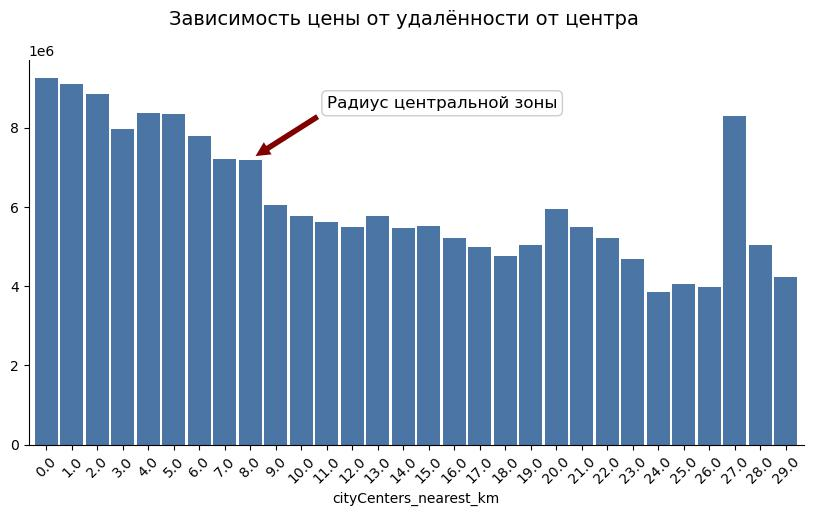

```python
# группировка значений по расстоянию до центра в километрах и подсчёт средней цены для каждого километра
fig = plt.figure(figsize=(10, 5))
ax1 = fig.add_subplot(1, 1, 1)
fig.suptitle('Зависимость цены от удалённости от центра', fontsize=14)
(flats_df
    .query('locality_name == "Санкт-Петербург"')
    .groupby('cityCenters_nearest_km')['last_price'].mean()
    .plot(kind='bar', x='cityCenters_nearest_km', y='last_price', color='#4A75A5', ax=ax1, width=0.9)
)
# построение столбчатого графика
plt.xticks(rotation = 45)
# изменение наклона подписей оси x
plt.annotate('Радиус центральной зоны', xy=(8, 7200000),  xycoords='data',
            xytext=(11, 8500000), textcoords='data', size=12,
            arrowprops=dict(facecolor='maroon', edgecolor='white', shrink=0.05, width=5),
            bbox=dict(boxstyle='round', alpha=0.2, facecolor='white'))
# добавление аннотации
plt.show()
# вывод на экран графика зависимости цены от удалённости от центра
```

Цена на квартиру пропорциональна ее местоположению: чем лучше расположение и социальная инфраструктура, тем выше стоимость квартиры. Также заметно небольшое повышение средней цены на расстоянии *4-5 км.* от центра, что может объясняться высокой стоимостью жилья в престижных районах, таких как Петроградский и Адмиралтейский.

Выделим категории на основе полученных результатов с применением *lambda-функции*.

```python
flats_df['locality_category'] = flats_df['cityCenters_nearest_km'].apply(lambda x: 'В центре города' if x <= 8 else ('В пределах города' if x > 8 and x <= 29 else ('Ленинградская область' if x > 29 else np.nan)))
# использование lambda-функции для категоризации квартир по местоположению
```

```python
flats_df['locality_category'].value_counts(dropna=False)
# просмотр уникальных значений 'locality_category'
```

```
В пределах города        12295
NaN                       5483
В центре города           3111
Ленинградская область     1393
Name: locality_category, dtype: int64
```

#### Высота потолков

```python
flats_df[flats_df['ceiling_height'].isna()].head()
# просмотр первых пяти строк с пропусками в столбце 'ceiling_height'
```

|  | total_images | last_price | total_area | first_day_exposition | rooms | ceiling_height | floors_total | living_area | floor | is_apartment | studio | open_plan | kitchen_area | balcony | locality_name | airports_nearest | cityCenters_nearest | parks_around3000 | parks_nearest | ponds_around3000 | ponds_nearest | days_exposition | cityCenters_nearest_km | locality_category |
| --- | --- | --- | --- | --- | --- | --- | --- | --- | --- | --- | --- | --- | --- | --- | --- | --- | --- | --- | --- | --- | --- | --- | --- | --- |
| 1 | 7 | 3350000.0 | 40.4 | 2018-12-04T00:00:00 | 1 | NaN | 11.0 | 18.6 | 1 | NaN | False | False | 11.0 | 2.0 | Шушары | 12817.0 | 18603.0 | 0.0 | NaN | 0.0 | NaN | 81.0 | 19.0 | В пределах города |
| 2 | 10 | 5196000.0 | 56.0 | 2015-08-20T00:00:00 | 2 | NaN | 5.0 | 34.3 | 4 | NaN | False | False | 8.3 | 0.0 | Санкт-Петербург | 21741.0 | 13933.0 | 1.0 | 90.0 | 2.0 | 574.0 | 558.0 | 14.0 | В пределах города |
| 5 | 10 | 2890000.0 | 30.4 | 2018-09-10T00:00:00 | 1 | NaN | 12.0 | 14.4 | 5 | NaN | False | False | 9.1 | NaN | Янино-1 | NaN | NaN | NaN | NaN | NaN | NaN | 55.0 | NaN | NaN |
| 6 | 6 | 3700000.0 | 37.3 | 2017-11-02T00:00:00 | 1 | NaN | 26.0 | 10.6 | 6 | NaN | False | False | 14.4 | 1.0 | Парголово | 52996.0 | 19143.0 | 0.0 | NaN | 0.0 | NaN | 155.0 | 19.0 | В пределах города |
| 7 | 5 | 7915000.0 | 71.6 | 2019-04-18T00:00:00 | 2 | NaN | 24.0 | NaN | 22 | NaN | False | False | 18.9 | 2.0 | Санкт-Петербург | 23982.0 | 11634.0 | 0.0 | NaN | 0.0 | NaN | NaN | 12.0 | В пределах города |

В историческом центре Санкт-Петербурга много старых домов с высокими потолками, которые в некоторых случаях могут *превышать 3 метра*. Такая архитектура квартир изначально была связана с использованием печного отопления и способствовала более эффективному распределению воздушных потоков в помещении. Более высокие потолки также позволяли устанавливать в квартирах большие окна, обеспечивая достаточное естественное освещение в условиях ограниченного доступа к электроэнергии.

Для более подробного изучения проведём анализ медианной высоты потолков в зависимости от местоположения квартир.

```python
flats_df.groupby('locality_category')['ceiling_height'].median()
# подсчёт медианной высоты потолков с использованием метода groupby
```

```
locality_category
В пределах города        2.60
В центре города          3.00
Ленинградская область    2.56
Name: ceiling_height, dtype: float64
```

Действительно, у квартир в центре города потолки выше.

Учтём это при заполнении пустых значений в колонке `ceiling_height`.

```python
for category in list(flats_df['locality_category'].unique()):
    flats_df.loc[((flats_df['locality_category'] == category) & (flats_df['ceiling_height'].isna())), 'ceiling_height'] = flats_df[flats_df['locality_category'] == category]['ceiling_height'].median()
# замена значений в столбце на основе условий
```

```python
flats_df['ceiling_height'].isna().sum()
# проверка числа пропусков в столбце 'ceiling_height'
```

```
2557
```

Заполним оставшиеся пропуски медианой по столбцу `ceiling_height`.

```python
flats_df['ceiling_height'].fillna(flats_df['ceiling_height'].median(), inplace=True)
# замена пропущенных значений медианой
```

```python
flats_df['ceiling_height'].isna().sum()
# проверка числа пропусков в столбце 'ceiling_height'
```

```
0
```

#### Число этажей в доме

```python
flats_df[flats_df['floors_total'].isna()].head()
# просмотр первых пяти строк с пропусками в столбце 'floors_total'
```

|  | total_images | last_price | total_area | first_day_exposition | rooms | ceiling_height | floors_total | living_area | floor | is_apartment | studio | open_plan | kitchen_area | balcony | locality_name | airports_nearest | cityCenters_nearest | parks_around3000 | parks_nearest | ponds_around3000 | ponds_nearest | days_exposition | cityCenters_nearest_km | locality_category |
| --- | --- | --- | --- | --- | --- | --- | --- | --- | --- | --- | --- | --- | --- | --- | --- | --- | --- | --- | --- | --- | --- | --- | --- | --- |
| 186 | 12 | 11640000.0 | 65.2 | 2018-10-02T00:00:00 | 2 | 2.6 | NaN | 30.80 | 4 | NaN | False | False | 12.00 | NaN | Санкт-Петербург | 39197.0 | 12373.0 | 1.0 | 123.0 | 0.0 | NaN | 49.0 | 12.0 | В пределах города |
| 237 | 4 | 2438033.0 | 28.1 | 2016-11-23T00:00:00 | 1 | 2.6 | NaN | 20.75 | 1 | NaN | False | False | NaN | 0.0 | Санкт-Петербург | 22041.0 | 17369.0 | 0.0 | NaN | 1.0 | 374.0 | 251.0 | 17.0 | В пределах города |
| 457 | 4 | 9788348.0 | 70.8 | 2015-08-01T00:00:00 | 2 | 3.0 | NaN | 38.40 | 12 | NaN | False | False | 10.63 | 0.0 | Санкт-Петербург | 37364.0 | 8322.0 | 2.0 | 309.0 | 2.0 | 706.0 | 727.0 | 8.0 | В центре города |
| 671 | 4 | 6051191.0 | 93.6 | 2017-04-06T00:00:00 | 3 | 2.6 | NaN | 47.10 | 8 | NaN | False | False | 16.80 | 0.0 | Санкт-Петербург | 22041.0 | 17369.0 | 0.0 | NaN | 1.0 | 374.0 | 123.0 | 17.0 | В пределах города |
| 1757 | 5 | 3600000.0 | 39.0 | 2017-04-22T00:00:00 | 1 | 2.6 | NaN | NaN | 9 | NaN | False | False | NaN | 0.0 | Санкт-Петербург | 22735.0 | 11618.0 | 1.0 | 835.0 | 1.0 | 652.0 | 77.0 | 12.0 | В пределах города |

```python
flats_df[flats_df['floors_total'].isna()]['floor'].count()
# подсчёт числа пропусков в столбце 'floors_total'
```

```
80
```

Доля пропусков невелика. Возможно, некоторые продавцы не включили общее количество этажей в основные характеристики, представленные в описании квартир. Здания с различным количеством этажей могут находиться как в центре города, так и в пригороде, поэтому невозможно заполнить пропущенные данные на основе имеющейся информации.

#### Жилая площадь и площадь кухни

```python
flats_df[flats_df['living_area'].isna()].head()
# просмотр первых пяти строк с пропусками в столбце 'living_area'
```

|  | total_images | last_price | total_area | first_day_exposition | rooms | ceiling_height | floors_total | living_area | floor | is_apartment | studio | open_plan | kitchen_area | balcony | locality_name | airports_nearest | cityCenters_nearest | parks_around3000 | parks_nearest | ponds_around3000 | ponds_nearest | days_exposition | cityCenters_nearest_km | locality_category |
| --- | --- | --- | --- | --- | --- | --- | --- | --- | --- | --- | --- | --- | --- | --- | --- | --- | --- | --- | --- | --- | --- | --- | --- | --- |
| 7 | 5 | 7915000.0 | 71.6 | 2019-04-18T00:00:00 | 2 | 2.6 | 24.0 | NaN | 22 | NaN | False | False | 18.9 | 2.0 | Санкт-Петербург | 23982.0 | 11634.0 | 0.0 | NaN | 0.0 | NaN | NaN | 12.0 | В пределах города |
| 30 | 12 | 2200000.0 | 32.8 | 2018-02-19T00:00:00 | 1 | 2.6 | 9.0 | NaN | 2 | NaN | False | False | NaN | NaN | Коммунар | NaN | NaN | NaN | NaN | NaN | NaN | 63.0 | NaN | NaN |
| 37 | 10 | 1990000.0 | 45.8 | 2017-10-28T00:00:00 | 2 | 2.5 | 5.0 | NaN | 1 | NaN | False | False | NaN | NaN | Красный Бор | NaN | NaN | NaN | NaN | NaN | NaN | 196.0 | NaN | NaN |
| 44 | 13 | 5350000.0 | 40.0 | 2018-11-18T00:00:00 | 1 | 2.6 | 22.0 | NaN | 3 | NaN | False | False | NaN | 1.0 | Санкт-Петербург | 30471.0 | 11603.0 | 1.0 | 620.0 | 1.0 | 1152.0 | NaN | 12.0 | В пределах города |
| 59 | 15 | 6300000.0 | 46.5 | 2017-03-06T00:00:00 | 1 | 2.6 | 13.0 | NaN | 13 | NaN | False | False | NaN | NaN | Санкт-Петербург | 11125.0 | 14501.0 | 0.0 | NaN | 0.0 | NaN | 336.0 | 15.0 | В пределах города |

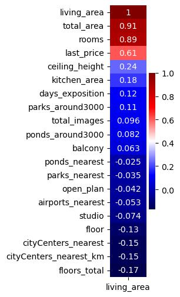

```python
living_area_correlation = flats_df.corr()[['living_area']].sort_values(by='living_area', ascending=False)
# корреляция жилой площади с другими характеристиками
plt.figure(figsize=(1,6))
sns.heatmap(living_area_correlation, cmap='seismic', annot=True)
plt.show()
# тепловая карта с коэффициентами корреляции Пирсона
```

Жилая площадь имеет высокую корреляцию с числом комнат и общей площадью, что предсказуемо. Общая площадь включает в себя как жилые пространства, так и другие нежилые помещения, такие как гардеробные, кладовые, кухни, коридоры и ванные комнаты. В то время как в жилую площадь входят спальни, детские и гостиные комнаты, которые в конечном итоге учитываются при подсчёте общего числа комнат в квартире. Таким образом, увеличение количества комнат влечёт за собой увеличение жилой площади.

```python
flats_df['total_area'].describe()
# получение описательной статистики для столбца 'total_area'
```

```
count    22282.000000
mean        54.285547
std         19.627621
min         12.000000
25%         39.300000
50%         50.000000
75%         65.000000
max        126.500000
Name: total_area, dtype: float64
```

```python
flats_df['total_area_category'] = flats_df['total_area'].apply(lambda x: 'Менее 39 кв.м.' if x < 39 else ('От 39 до 50 кв.м.' if x >= 39 and x < 50 else ('От 50 до 65 кв.м.' if x >= 50 and x < 65 else ('Более 65 кв.м.' if x >= 65 else np.nan))))
# категоризация квартир по общей площади с помощью lambda-функции
```

```python
flats_df.groupby('total_area_category')['living_area'].agg(['count', 'median'])
# группировка по категориям общей площади с подсчётом медианной жилой площади
```

| total_area_category | count | median |
| --- | --- | --- |
| Более 65 кв.м. | 5259 | 47.0 |
| Менее 39 кв.м. | 4909 | 17.0 |
| От 39 до 50 кв.м. | 5154 | 26.0 |
| От 50 до 65 кв.м. | 5216 | 33.0 |

```python
for room_count in list(flats_df['rooms'].unique()):
    for category in list(flats_df['total_area_category'].unique()):
        flats_df.loc[((flats_df['rooms'] == room_count) & (flats_df['total_area_category'] == category) & (flats_df['living_area'].isna())), 'living_area'] = flats_df[(flats_df['total_area_category'] == category) & (flats_df['rooms'] == room_count)]['living_area'].median()
# замена значений в столбце с учётом количества комнат и общей площади
```

```python
flats_df[flats_df['living_area'].isna()]['total_area'].count()
# подсчёт числа пропусков в столбце 'living_area'
```

```
0
```

Все пропущенные значения заполнились.

```python
flats_df[flats_df['kitchen_area'].isna()].head()
# просмотр первых пяти строк с пропусками в столбце 'kitchen_area'
```

|  | total_images | last_price | total_area | first_day_exposition | rooms | ceiling_height | floors_total | living_area | floor | is_apartment | studio | open_plan | kitchen_area | balcony | locality_name | airports_nearest | cityCenters_nearest | parks_around3000 | parks_nearest | ponds_around3000 | ponds_nearest | days_exposition | cityCenters_nearest_km | locality_category | total_area_category |
| --- | --- | --- | --- | --- | --- | --- | --- | --- | --- | --- | --- | --- | --- | --- | --- | --- | --- | --- | --- | --- | --- | --- | --- | --- | --- |
| 30 | 12 | 2200000.0 | 32.8 | 2018-02-19T00:00:00 | 1 | 2.6 | 9.0 | 17.0 | 2 | NaN | False | False | NaN | NaN | Коммунар | NaN | NaN | NaN | NaN | NaN | NaN | 63.0 | NaN | NaN | Менее 39 кв.м. |
| 37 | 10 | 1990000.0 | 45.8 | 2017-10-28T00:00:00 | 2 | 2.5 | 5.0 | 28.1 | 1 | NaN | False | False | NaN | NaN | Красный Бор | NaN | NaN | NaN | NaN | NaN | NaN | 196.0 | NaN | NaN | От 39 до 50 кв.м. |
| 44 | 13 | 5350000.0 | 40.0 | 2018-11-18T00:00:00 | 1 | 2.6 | 22.0 | 18.4 | 3 | NaN | False | False | NaN | 1.0 | Санкт-Петербург | 30471.0 | 11603.0 | 1.0 | 620.0 | 1.0 | 1152.0 | NaN | 12.0 | В пределах города | От 39 до 50 кв.м. |
| 59 | 15 | 6300000.0 | 46.5 | 2017-03-06T00:00:00 | 1 | 2.6 | 13.0 | 18.4 | 13 | NaN | False | False | NaN | NaN | Санкт-Петербург | 11125.0 | 14501.0 | 0.0 | NaN | 0.0 | NaN | 336.0 | 15.0 | В пределах города | От 39 до 50 кв.м. |
| 60 | 3 | 2740000.0 | 35.0 | 2018-01-01T00:00:00 | 1 | 2.6 | 12.0 | 17.0 | 8 | NaN | False | False | NaN | NaN | Мурино | NaN | NaN | NaN | NaN | NaN | NaN | 11.0 | NaN | NaN | Менее 39 кв.м. |

Размеры кухни могут варьироваться в зависимости от конфигурации многоквартирных домов и индивидуальных предпочтений владельцев. Поэтому, оставим эту колонку как есть.

#### Количество балконов

```python
flats_df[flats_df['balcony'].isna()].head()
# просмотр первых пяти строк с пропусками в столбце 'balcony'
```

|  | total_images | last_price | total_area | first_day_exposition | rooms | ceiling_height | floors_total | living_area | floor | is_apartment | studio | open_plan | kitchen_area | balcony | locality_name | airports_nearest | cityCenters_nearest | parks_around3000 | parks_nearest | ponds_around3000 | ponds_nearest | days_exposition | cityCenters_nearest_km | locality_category | total_area_category |
| --- | --- | --- | --- | --- | --- | --- | --- | --- | --- | --- | --- | --- | --- | --- | --- | --- | --- | --- | --- | --- | --- | --- | --- | --- | --- |
| 0 | 20 | 13000000.0 | 108.00 | 2019-03-07T00:00:00 | 3 | 2.70 | 16.0 | 51.00 | 8 | NaN | False | False | 25.00 | NaN | Санкт-Петербург | 18863.0 | 16028.0 | 1.0 | 482.0 | 2.0 | 755.0 | NaN | 16.0 | В пределах города | Более 65 кв.м. |
| 4 | 2 | 10000000.0 | 100.00 | 2018-06-19T00:00:00 | 2 | 3.03 | 14.0 | 32.00 | 13 | NaN | False | False | 41.00 | NaN | Санкт-Петербург | 31856.0 | 8098.0 | 2.0 | 112.0 | 1.0 | 48.0 | 121.0 | 8.0 | В центре города | Более 65 кв.м. |
| 5 | 10 | 2890000.0 | 30.40 | 2018-09-10T00:00:00 | 1 | 2.60 | 12.0 | 14.40 | 5 | NaN | False | False | 9.10 | NaN | Янино-1 | NaN | NaN | NaN | NaN | NaN | NaN | 55.0 | NaN | NaN | Менее 39 кв.м. |
| 8 | 20 | 2900000.0 | 33.16 | 2018-05-23T00:00:00 | 1 | 2.60 | 27.0 | 15.43 | 26 | NaN | False | False | 8.81 | NaN | Мурино | NaN | NaN | NaN | NaN | NaN | NaN | 189.0 | NaN | NaN | Менее 39 кв.м. |
| 10 | 5 | 5050000.0 | 39.60 | 2017-11-16T00:00:00 | 1 | 2.67 | 12.0 | 20.30 | 3 | NaN | False | False | 8.50 | NaN | Санкт-Петербург | 38357.0 | 13878.0 | 1.0 | 310.0 | 2.0 | 553.0 | 137.0 | 14.0 | В пределах города | От 39 до 50 кв.м. |

Скорее всего, число балконов пропущено в объявлениях, которые содержат информацию о квартирах вообще без балконов. Исходя из количества строк с пропусками, можно предположить, что у половины квартир отсутствуют балконы, что соответствует действительности.

```python
flats_df['balcony'].fillna(0, inplace=True)
# замена пропущенных значений на 0
```

#### Количество дней, в течение которых было размещено объявление

```python
flats_df[flats_df['days_exposition'].isna()].head()
# просмотр первых пяти строк с пропусками в столбце 'days_exposition'
```

|  | total_images | last_price | total_area | first_day_exposition | rooms | ceiling_height | floors_total | living_area | floor | is_apartment | studio | open_plan | kitchen_area | balcony | locality_name | airports_nearest | cityCenters_nearest | parks_around3000 | parks_nearest | ponds_around3000 | ponds_nearest | days_exposition | cityCenters_nearest_km | locality_category | total_area_category |
| --- | --- | --- | --- | --- | --- | --- | --- | --- | --- | --- | --- | --- | --- | --- | --- | --- | --- | --- | --- | --- | --- | --- | --- | --- | --- |
| 0 | 20 | 13000000.0 | 108.0 | 2019-03-07T00:00:00 | 3 | 2.70 | 16.0 | 51.0 | 8 | NaN | False | False | 25.0 | 0.0 | Санкт-Петербург | 18863.0 | 16028.0 | 1.0 | 482.0 | 2.0 | 755.0 | NaN | 16.0 | В пределах города | Более 65 кв.м. |
| 7 | 5 | 7915000.0 | 71.6 | 2019-04-18T00:00:00 | 2 | 2.60 | 24.0 | 37.0 | 22 | NaN | False | False | 18.9 | 2.0 | Санкт-Петербург | 23982.0 | 11634.0 | 0.0 | NaN | 0.0 | NaN | NaN | 12.0 | В пределах города | Более 65 кв.м. |
| 44 | 13 | 5350000.0 | 40.0 | 2018-11-18T00:00:00 | 1 | 2.60 | 22.0 | 18.4 | 3 | NaN | False | False | NaN | 1.0 | Санкт-Петербург | 30471.0 | 11603.0 | 1.0 | 620.0 | 1.0 | 1152.0 | NaN | 12.0 | В пределах города | От 39 до 50 кв.м. |
| 45 | 17 | 5200000.0 | 50.6 | 2018-12-02T00:00:00 | 2 | 2.65 | 9.0 | 30.3 | 7 | NaN | False | False | 7.0 | 0.0 | Санкт-Петербург | 30011.0 | 12872.0 | 0.0 | NaN | 0.0 | NaN | NaN | 13.0 | В пределах города | От 50 до 65 кв.м. |
| 46 | 17 | 6600000.0 | 52.1 | 2019-01-31T00:00:00 | 2 | 2.60 | 24.0 | 29.7 | 9 | NaN | False | False | 8.3 | 2.0 | Санкт-Петербург | 15114.0 | 12702.0 | 0.0 | NaN | 0.0 | NaN | NaN | 13.0 | В пределах города | От 50 до 65 кв.м. |

Отсутствие данных в столбце `days_exposition` может быть связано с тем, что пользователи сервиса не сняли или забыли снять свои объявления о продаже квартир с публикации на сайте, даже если сделки фактически уже завершились. Высокий процент отсутствующих значений *(13%)* делает невозможным заполнение пропусков с использованием медианы или среднего значения, так как это может привести к искажению результатов в данном случае.

В остальных столбцах `parks_around3000`, `parks_nearest`, `ponds_around3000`, `ponds_nearest`, `is_apartment` заполнять пропуски нет необходимости. Они не будут использоваться в дальнейшем анализе.

```python
flats_df.isna().sum()
# проверка количества пропусков в каждом столбце
```

```
total_images                  0
last_price                    0
total_area                    0
first_day_exposition          0
rooms                         0
ceiling_height                0
floors_total                 80
living_area                   0
floor                         0
is_apartment              19687
studio                        0
open_plan                     0
kitchen_area               2138
balcony                       0
locality_name                 0
airports_nearest           5499
cityCenters_nearest        5483
parks_around3000           5482
parks_nearest             15155
ponds_around3000           5482
ponds_nearest             14128
days_exposition            2788
cityCenters_nearest_km     5483
locality_category          5483
total_area_category           0
dtype: int64
```

### Изменение типов данных

```python
flats_df.dtypes
# вызов атрибута dtypes с типами данных
```

```
total_images                int64
last_price                float64
total_area                float64
first_day_exposition       object
rooms                       int64
ceiling_height            float64
floors_total              float64
living_area               float64
floor                       int64
is_apartment               object
studio                       bool
open_plan                    bool
kitchen_area              float64
balcony                   float64
locality_name              object
airports_nearest          float64
cityCenters_nearest       float64
parks_around3000          float64
parks_nearest             float64
ponds_around3000          float64
ponds_nearest             float64
days_exposition           float64
cityCenters_nearest_km    float64
locality_category          object
total_area_category        object
dtype: object
```

Для корректного отображения даты и времени используем метод *to_datetime()*.

```python
flats_df['first_day_exposition'] = pd.to_datetime(flats_df['first_day_exposition'], format='%Y-%m-%dT%H:%M:%S')
# перевод столбца 'first_day_exposition' в формат datetime
```

Дальше преобразуем столбцы `last_price` и `balcony` в целочисленный тип. Количество балконов не может быть числом с плавающей точкой, а цены проще сопоставлять и анализировать в рублях без учёта копеек.

```python
for column in ['last_price', 'balcony']:
    flats_df[column] = flats_df[column].astype('int')
# использование цикла для перевода данных в тип int методом astype
```

Высоту потолков, размер квартир, а также расстояние до парков, водоёмов, аэропорта и центра города лучше округлить до 1 знака после запятой. При покупке недвижимости некоторым людям важно учитывать точные значения этих параметров.

```python
for column in ['ceiling_height', 'total_area', 'living_area', 'kitchen_area', 'airports_nearest', 'cityCenters_nearest', 'parks_nearest', 'ponds_nearest']:
    flats_df[column] = flats_df[column].round(1)
# использование цикла для округления чисел до 1 знака после запятой
```

```python
flats_df.dtypes
# проверка типов данных
```

```
total_images                       int64
last_price                         int64
total_area                       float64
first_day_exposition      datetime64[ns]
rooms                              int64
ceiling_height                   float64
floors_total                     float64
living_area                      float64
floor                              int64
is_apartment                      object
studio                              bool
open_plan                           bool
kitchen_area                     float64
balcony                            int64
locality_name                     object
airports_nearest                 float64
cityCenters_nearest              float64
parks_around3000                 float64
parks_nearest                    float64
ponds_around3000                 float64
ponds_nearest                    float64
days_exposition                  float64
cityCenters_nearest_km           float64
locality_category                 object
total_area_category               object
dtype: object
```

```python
flats_df.head()
# вывод первых 5 строк датафрейма
```

|  | total_images | last_price | total_area | first_day_exposition | rooms | ceiling_height | floors_total | living_area | floor | is_apartment | studio | open_plan | kitchen_area | balcony | locality_name | airports_nearest | cityCenters_nearest | parks_around3000 | parks_nearest | ponds_around3000 | ponds_nearest | days_exposition | cityCenters_nearest_km | locality_category | total_area_category |
| --- | --- | --- | --- | --- | --- | --- | --- | --- | --- | --- | --- | --- | --- | --- | --- | --- | --- | --- | --- | --- | --- | --- | --- | --- | --- |
| 0 | 20 | 13000000 | 108.0 | 2019-03-07 | 3 | 2.7 | 16.0 | 51.0 | 8 | NaN | False | False | 25.0 | 0 | Санкт-Петербург | 18863.0 | 16028.0 | 1.0 | 482.0 | 2.0 | 755.0 | NaN | 16.0 | В пределах города | Более 65 кв.м. |
| 1 | 7 | 3350000 | 40.4 | 2018-12-04 | 1 | 2.6 | 11.0 | 18.6 | 1 | NaN | False | False | 11.0 | 2 | Шушары | 12817.0 | 18603.0 | 0.0 | NaN | 0.0 | NaN | 81.0 | 19.0 | В пределах города | От 39 до 50 кв.м. |
| 2 | 10 | 5196000 | 56.0 | 2015-08-20 | 2 | 2.6 | 5.0 | 34.3 | 4 | NaN | False | False | 8.3 | 0 | Санкт-Петербург | 21741.0 | 13933.0 | 1.0 | 90.0 | 2.0 | 574.0 | 558.0 | 14.0 | В пределах города | От 50 до 65 кв.м. |
| 4 | 2 | 10000000 | 100.0 | 2018-06-19 | 2 | 3.0 | 14.0 | 32.0 | 13 | NaN | False | False | 41.0 | 0 | Санкт-Петербург | 31856.0 | 8098.0 | 2.0 | 112.0 | 1.0 | 48.0 | 121.0 | 8.0 | В центре города | Более 65 кв.м. |
| 5 | 10 | 2890000 | 30.4 | 2018-09-10 | 1 | 2.6 | 12.0 | 14.4 | 5 | NaN | False | False | 9.1 | 0 | Янино-1 | NaN | NaN | NaN | NaN | NaN | NaN | 55.0 | NaN | NaN | Менее 39 кв.м. |

## Посчитайте и добавьте в таблицу новые столбцы

Сначала добавим в таблицу столбец с ценой квадратного метра.

```python
flats_df['price_for_square_meter'] = (flats_df['last_price'] / flats_df['total_area']).round(2)
# создание столбца с ценой за квадратный метр
```

Далее создаём колонки с днём, месяцем и годом публикации объявлений.

```python
flats_df['weekday'] = flats_df['first_day_exposition'].dt.weekday
# определение дня недели публикации на основе колонки с датой
```

```python
flats_df['weekday_name'] = flats_df['weekday'].apply(lambda x: 'понедельник' if x == 0 else ('вторник' if x == 1 else ('среда' if x == 2 else ('четверг' if x == 3 else ('пятница' if x == 4 else ('суббота' if x == 5 else ('воскресенье' if x == 6 else np.nan)))))))
# определение названий дней недели с помощью lambda-функции
```

```python
flats_df['weekday_name'].value_counts(dropna=False)
# подсчёт количества строк по дням недели
```

```
четверг        3984
вторник        3958
пятница        3782
среда          3720
понедельник    3392
суббота        1831
воскресенье    1615
Name: weekday_name, dtype: int64
```

```python
flats_df['month'] = flats_df['first_day_exposition'].dt.month
# определение месяца публикации на основе колонки с датой
```

```python
flats_df['year'] = flats_df['first_day_exposition'].dt.year
# определение года публикации на основе колонки с датой
```

Создадим категоризацию квартир по типу этажа: 'первый', 'последний', 'другой'.

```python
def get_floor_category(row):
    try:
        if row['floor'] == row['floors_total']:
            return 'последний'
        if row['floor'] == 1:
            return 'первый'
        else:
            return 'другой'
    except:
        return np.nan
# создание функции для категоризации квартир в зависимости от этажа
flats_df['floor_category'] = flats_df.apply(get_floor_category, axis=1)
# применение функции get_floor_category ко всему датафрейму с созданием нового столбца 'floor_category'
```

```python
flats_df['floor_category'].value_counts(dropna=False)
# подсчёт количества строк по типам этажей
```

```
другой       16376
последний     3098
первый        2808
Name: floor_category, dtype: int64
```

```python
flats_df.head()
# вывод первых 5 строк датафрейма
```

|  | total_images | last_price | total_area | first_day_exposition | rooms | ceiling_height | floors_total | living_area | floor | is_apartment | studio | open_plan | kitchen_area | balcony | locality_name | airports_nearest | cityCenters_nearest | parks_around3000 | parks_nearest | ponds_around3000 | ponds_nearest | days_exposition | cityCenters_nearest_km | locality_category | total_area_category | price_for_square_meter | weekday | weekday_name | month | … |
| --- | --- | --- | --- | --- | --- | --- | --- | --- | --- | --- | --- | --- | --- | --- | --- | --- | --- | --- | --- | --- | --- | --- | --- | --- | --- | --- | --- | --- | --- | --- |
| 0 | 20 | 13000000 | 108.0 | 2019-03-07 | 3 | 2.7 | 16.0 | 51.0 | 8 | NaN | False | False | 25.0 | 0 | Санкт-Петербург | 18863.0 | 16028.0 | 1.0 | 482.0 | 2.0 | 755.0 | NaN | 16.0 | В пределах города | Более 65 кв.м. | 120370.37 | 3 | четверг | 3 | … |
| 1 | 7 | 3350000 | 40.4 | 2018-12-04 | 1 | 2.6 | 11.0 | 18.6 | 1 | NaN | False | False | 11.0 | 2 | Шушары | 12817.0 | 18603.0 | 0.0 | NaN | 0.0 | NaN | 81.0 | 19.0 | В пределах города | От 39 до 50 кв.м. | 82920.79 | 1 | вторник | 12 | … |
| 2 | 10 | 5196000 | 56.0 | 2015-08-20 | 2 | 2.6 | 5.0 | 34.3 | 4 | NaN | False | False | 8.3 | 0 | Санкт-Петербург | 21741.0 | 13933.0 | 1.0 | 90.0 | 2.0 | 574.0 | 558.0 | 14.0 | В пределах города | От 50 до 65 кв.м. | 92785.71 | 3 | четверг | 8 | … |
| 4 | 2 | 10000000 | 100.0 | 2018-06-19 | 2 | 3.0 | 14.0 | 32.0 | 13 | NaN | False | False | 41.0 | 0 | Санкт-Петербург | 31856.0 | 8098.0 | 2.0 | 112.0 | 1.0 | 48.0 | 121.0 | 8.0 | В центре города | Более 65 кв.м. | 100000.00 | 1 | вторник | 6 | … |
| 5 | 10 | 2890000 | 30.4 | 2018-09-10 | 1 | 2.6 | 12.0 | 14.4 | 5 | NaN | False | False | 9.1 | 0 | Янино-1 | NaN | NaN | NaN | NaN | NaN | NaN | 55.0 | NaN | NaN | Менее 39 кв.м. | 95065.79 | 0 | понедельник | 9 | … |

## Проведите исследовательский анализ данных

### Изучите параметры объектов и постройте отдельные гистограммы для каждого из этих параметров.

```python
def plot_hist(column, column_name, x_range=(0, 200), number_of_bins=25):
    fig_total_area = plt.figure(figsize=(9,5))
    ax1 = fig_total_area.add_subplot(1,1,1)
    ax1.grid(which='major', linewidth=1, color='gray', alpha=0.2)
    ax1.set_title(f'Распределение параметра: {column_name}', fontsize=14)
    sns.histplot(x=column, data=flats_df, ax=ax1, color='#0D3578', bins=number_of_bins).set(xlim=x_range)

    plt.show()
# создание функции для вывода гистограмм распределения разных параметров
```

#### Общая площадь, жилая площадь и площадь кухни

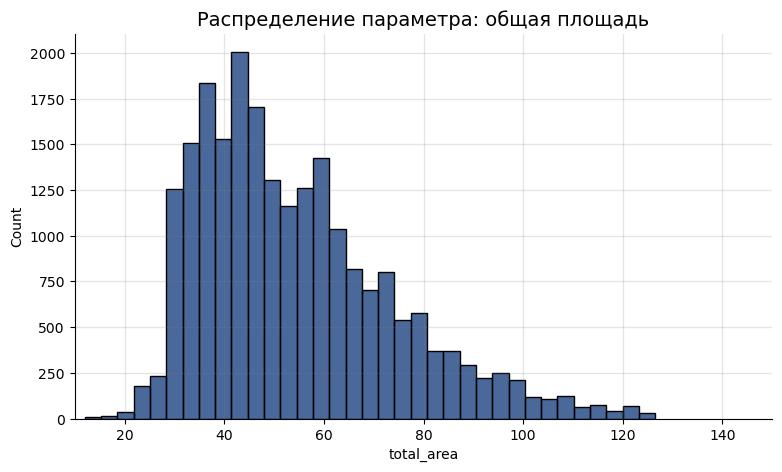

```python
plot_hist('total_area', 'общая площадь', (10, 150), 35)
# вывод гистограммы распределения общих площадей квартир
```

Значительная часть квартир в анализируемой выборке имеет площадь **от 30 до 60 квадратных метров**, причём наиболее распространённой площадью жилья является примерно 40-45 квадратных метров. Квартиры, с площадью *свыше 70 квадратных метров*, чаще всего представлены четырёх- и пятикомнатными вариантами и встречаются реже. Самые небольшие квартиры имеют размер *от 12 до 30 квадратных метров* и чаще всего представлены студиями, особенно в переделанных коммунальных квартирах.

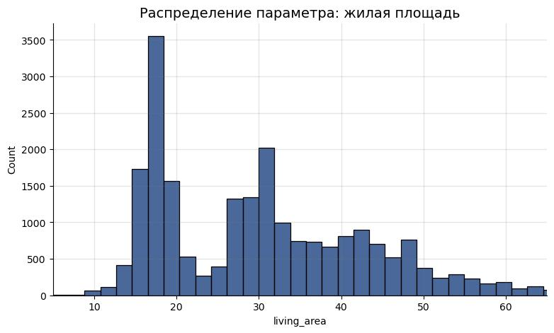

```python
plot_hist('living_area', 'жилая площадь', (5, 65), 50)
# вывод гистограммы распределения жилых площадей квартир
```

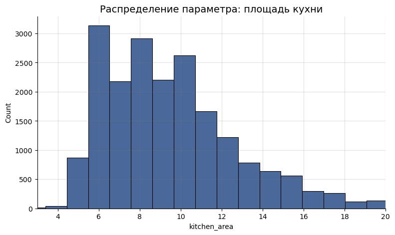

```python
plot_hist('kitchen_area', 'площадь кухни', (3, 20), 60)
# вывод гистограммы распределения площадей кухонь
```

#### Цена объекта

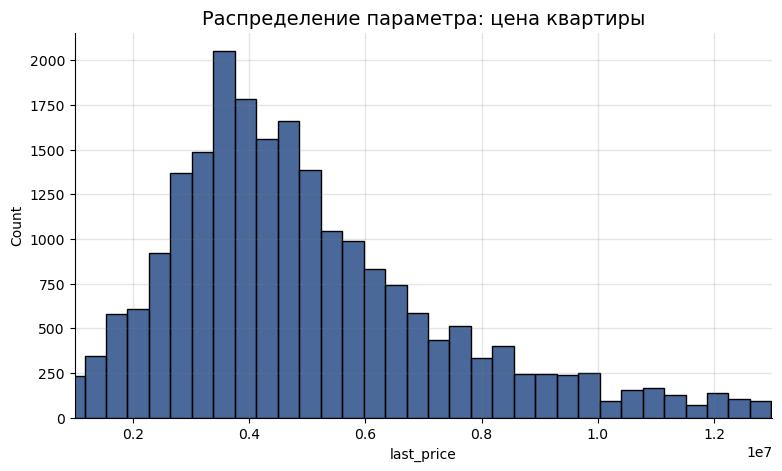

```python
plot_hist('last_price', 'цена квартиры', (1000000, 13000000), 40)
# вывод гистограммы распределения цен объектов
```

Для наглядности переведём столбец с ценой объектов из рублей в млн. рублей.

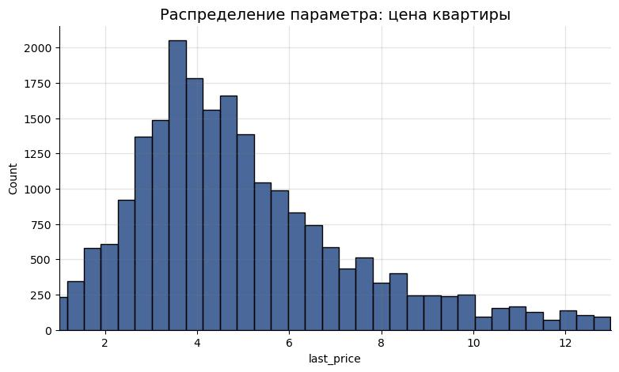

```python
flats_df['last_price'] = flats_df['last_price'] / 1000000
plot_hist('last_price', 'цена квартиры', (1, 13), 40)
# вывод гистограммы распределения цен объектов
```

Средняя цена квартиры составляет **4.5 млн.руб.** Гистограмма распределения цен достигает своего максимума около отметки в 3.6 млн.руб., обладает "хвостом" справа. Недорогое жилье, возможно, представлено квартирами в Ленинградской области, удалёнными от аэропорта, с низкой транспортной доступностью и отсутствием разнообразных услуг вокруг.

#### Количество комнат и высота потолка

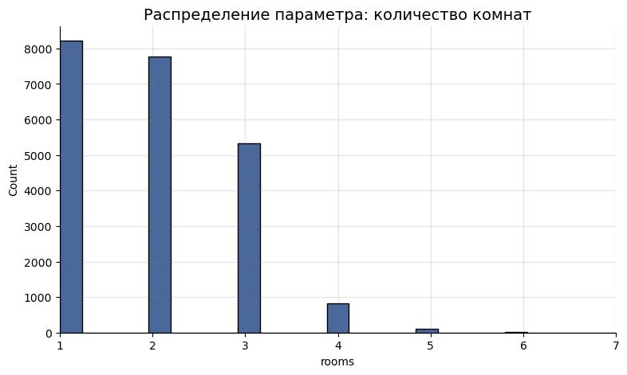

```python
plot_hist('rooms', 'количество комнат', (1, 7))
# вывод гистограммы распределения количества комнат
```

Самые популярные квартиры имеют **от 1 до 3 комнат**. 1-комнатные квартиры - это небольшие студии, а многокомнатные положительно коррелируют с общей площадью.

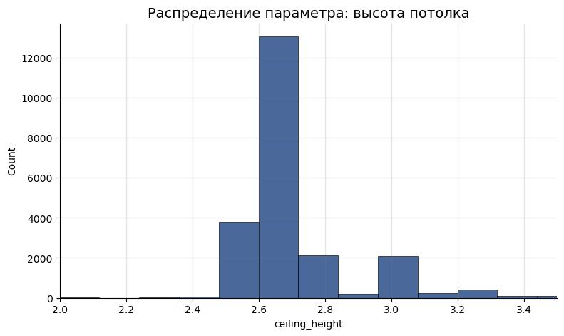

```python
plot_hist('ceiling_height', 'высота потолка', (2, 3.5), 100)
# вывод гистограммы распределения высоты потолков в квартирах
```

Наиболее распространены квартиры с потолками **от стандартных 2.5 до 2.8 метров**. Потолки высотой *3 метра* преимущественно встречаются в "сталинках" и жилых домах с панельной конструкцией, таких как 137-я серия. Кроме того, на рынке недвижимости в Санкт-Петербурге можно встретить целые особняки, преобразованные в семейные апартаменты или одну большую квартиру с несколькими уровнями, где высота потолков составляет *5 метров и более*. С другой стороны, существуют варианты квартир с низкими потолками, например, в домах серии ГИ, где высота в среднем составляет *2.4 метра*, а в санузлах - 2.3 метра.

#### Общее количество этажей в доме и тип этажа

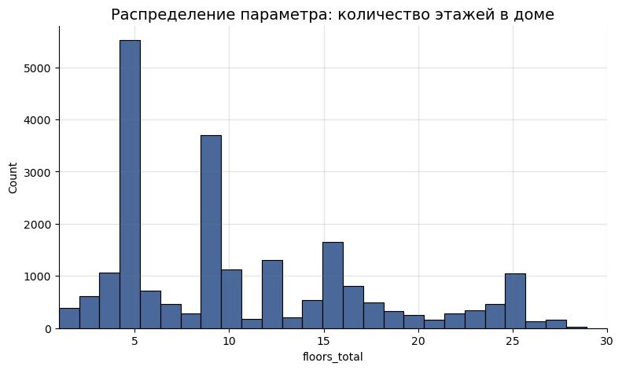

```python
plot_hist('floors_total', 'количество этажей в доме', (1, 30), 55)
# вывод гистограммы распределения числа этажей в домах
```

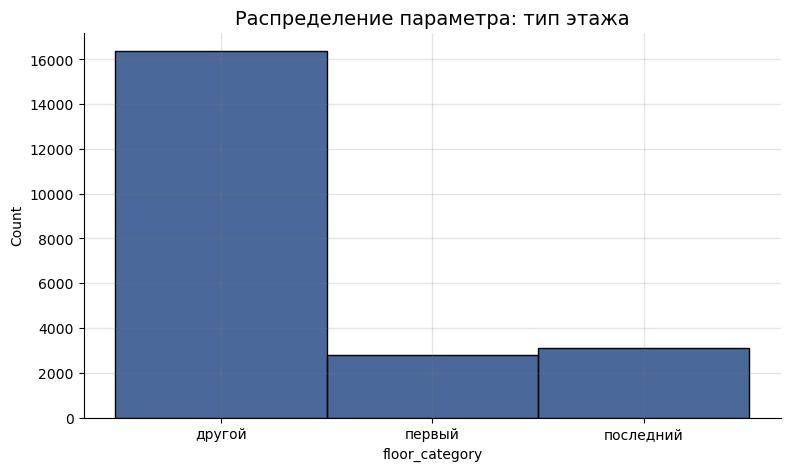

```python
plot_hist('floor_category', 'тип этажа', x_range=None, number_of_bins=None)
# вывод гистограммы распределения по типам этажей
```

Четверть всей выборки представляют собой **пятиэтажные здания**, что отражено на графике распределения общего количества этажей. На втором месте по популярности в объявлениях находятся квартиры в девятиэтажных домах.

#### Расстояние до центра города и до ближайшего парка в метрах

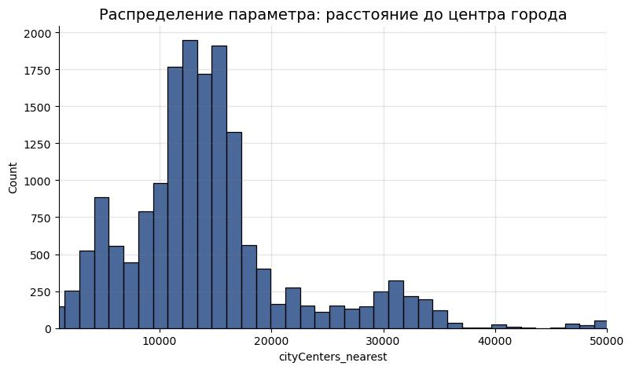

```python
plot_hist('cityCenters_nearest', 'расстояние до центра города', x_range=(1000, 50000), number_of_bins=50)
# вывод гистограммы распределения расстояний до центра города
```

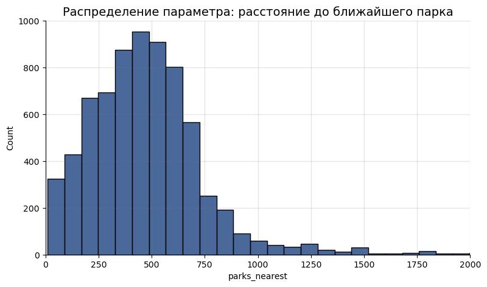

```python
plot_hist('parks_nearest', 'расстояние до ближайшего парка', x_range=(0, 2000), number_of_bins=40)
# вывод гистограммы распределения расстояний до ближайшего парка
```

Половина квартир, выставленных на продажу, расположена в пределах города в диапазоне **от 10 до 17 км.** (спальные районы Санкт-Петербурга).

Медианное значение расстояния до ближайшего парка составляет **457 метров**.

### Изучите, как быстро продавались квартиры (столбец days_exposition).

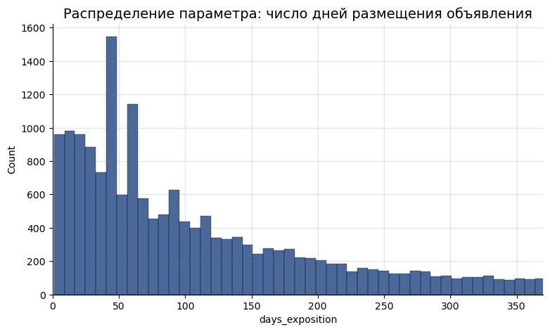

```python
plot_hist('days_exposition', 'число дней размещения объявления', x_range=(0, 370), number_of_bins=200)
# вывод гистограммы распределения дней размещения объявлений
```

```python
flats_df['days_exposition'].describe()
# получение описательной статистики для столбца 'days_exposition'
```

```
count    19494.000000
mean       175.056069
std        213.677551
min          1.000000
25%         44.000000
50%         92.000000
75%        222.000000
max       1580.000000
Name: days_exposition, dtype: float64
```

Средний период времени, в течение которого происходит продажа квартиры, составляет 175 дней, в то время как медианный срок – **92 дня**. Вероятно, среднее значение подвержено смещению из-за наличия выбросов. Например, максимальное количество дней размещения объявления равно *1580 дням или 4.3 года*. Возможно, в данном случае человек просто забыл снять объявление с публикации, несмотря на то, что сделка уже была завершена.

Ещё одной особенностью данного распределения являются два пиковых значения по числу проданных квартир. Далее необходимо более детально изучить срез данных в интервале *от 20 до 70 дней*.

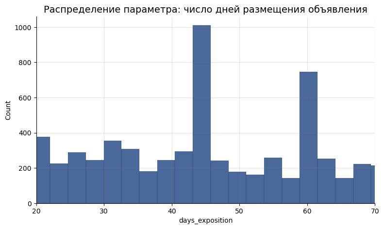

```python
plot_hist('days_exposition', 'число дней размещения объявления', x_range=(20, 70), number_of_bins=600)
# вывод гистограммы распределения по числу дней размещения объявлений (от 20 до 70)
```

Высокие значения, наблюдаемые при **45 и 60 днях** на графике, могут быть обусловлены *правилами бесплатной публикации объявлений* на платформе Яндекс.Недвижимость. Для квартир, стоимость которых не превышает 4.5 млн.руб., срок публикации был ограничен 45 днями, а для квартир стоимостью от 4.5 до 10 млн.руб. – 60 днями. Следовательно, платные публикации могли вызвать указанные пики на графике. Важно учесть, что с течением времени тарифы для Москвы, Санкт-Петербурга и их областей изменились и увеличился срок бесплатного размещения объявлений. Поэтому необходимо уточнить, с какого момента начали действовать новые правила, и рассмотреть две выборки по отдельности.

В общем, стандартный срок продажи квартиры составляет примерно **три месяца**. Быстрые продажи, как правило, занимают *не более 20-25 дней*. Часто для ускорения процесса сделки продавцам приходится идти на уступки и снижать цену. Если же продажи затягиваются *более чем на 500 дней (1.5 года)*, такой срок можно считать долгим. Причины долгих продаж часто включают завышенную цену и неполный пакет документов.

### Какие факторы больше всего влияют на общую (полную) стоимость объекта?

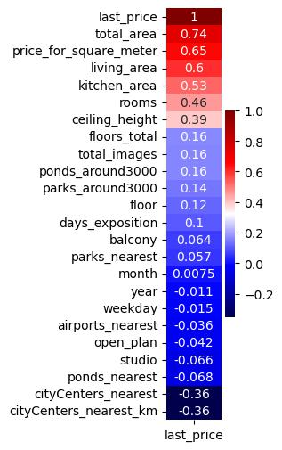

```python
price_correlation = flats_df.corr()[['last_price']].sort_values(by='last_price', ascending=False)
# корреляция цены объекта с другими характеристиками
plt.figure(figsize=(1,6))
sns.heatmap(price_correlation, cmap='seismic', annot=True)
plt.show()
# тепловая карта с коэффициентами корреляции Пирсона
```

Цена квартиры сильнее всего коррелирует **с общей площадью (0.74)**, а также **с жилой площадью (0.6) и площадью кухни (0.53)**. Чем просторнее квартира, тем выше её цена. Кроме того, имеется небольшая положительная корреляция с количеством *комнат и высотой потолков*. Наличие парков и водоёмов также оказывает некоторое воздействие на изменение цены в сторону её увеличения. С другой стороны, отмечается обратная связь между расстоянием от центра и ценой, что отражается в отрицательном коэффициенте корреляции.

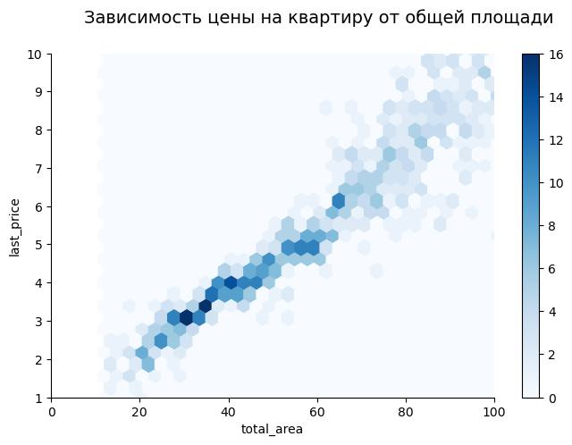

```python
fig = plt.figure(figsize=(8, 5))
fig.suptitle('Зависимость цены на квартиру от общей площади', fontsize=14)
ax1 = fig.add_subplot(1, 1, 1)
(flats_df
    .groupby('total_area')['last_price'].median().reset_index()
    .plot(x='total_area', y='last_price', kind='hexbin', ax=ax1, gridsize=40, cmap='Blues')
)
plt.xlim([0, 100])
plt.ylim([1, 10])

plt.show()
# построение диаграммы рассеяния типа hexbin
```

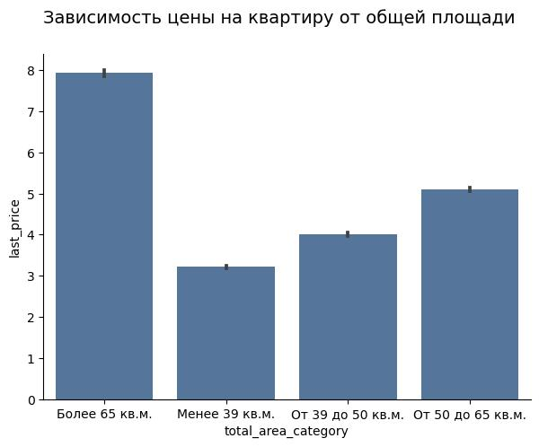

```python
fig = plt.figure(figsize=(7, 5))
fig.suptitle('Зависимость цены на квартиру от общей площади', fontsize=14)
ax1 = fig.add_subplot(1, 1, 1)
sns.barplot(data=flats_df.sort_values(by='total_area_category'), x='total_area_category', y='last_price', color='#4A75A5')

plt.show()
# построение столбчатой диараммы с зависимостью цены на квартиру от общей площади
```

В пределах **от 20 до 60 кв.м.** наблюдается ярко выраженная *линейная зависимость* между общей площадью и ценой квартиры. С течением времени эта зависимость постепенно ослабевает, и разброс значений становится более заметным. Возможно, это объясняется наличием в выборке объявлений о продаже больших квартир в центре Санкт-Петербурга, где цена за квадратный метр в среднем составляет 110 тыс.руб. Кроме того, квартиры с одинаковой площадью могут относиться к различным типам жилья: старому фонду или полностью реконструированным домам. Как правило, квартиры в старых домах имеют изношенные коммуникации, что, соответственно, сказывается на их цене.

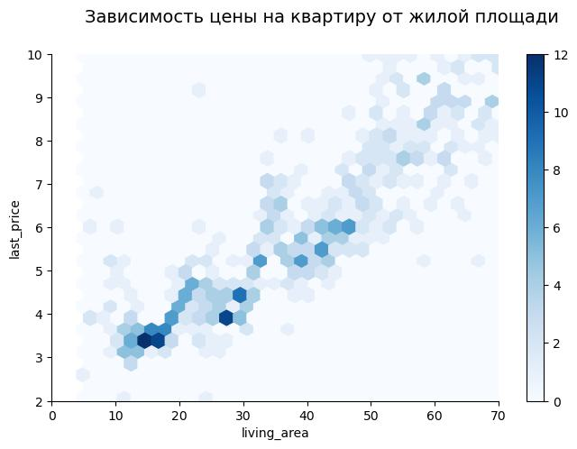

```python
fig = plt.figure(figsize=(8, 5))
fig.suptitle('Зависимость цены на квартиру от жилой площади', fontsize=14)
ax1 = fig.add_subplot(1, 1, 1)
(flats_df
    .groupby('living_area')['last_price'].median().reset_index()
    .plot(x='living_area', y='last_price', kind='hexbin', ax=ax1, gridsize=45, cmap='Blues')
)
plt.xlim([0, 70])
plt.ylim([2, 10])

plt.show()
# построение диаграммы рассеяния типа hexbin
```

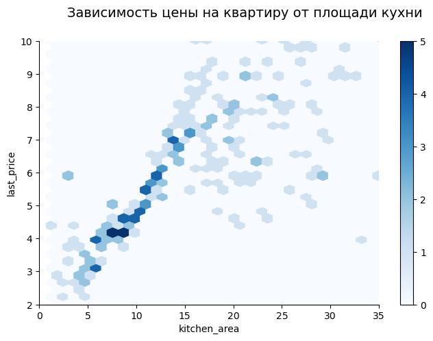

```python
fig = plt.figure(figsize=(8, 5))
fig.suptitle('Зависимость цены на квартиру от площади кухни', fontsize=14)
ax1 = fig.add_subplot(1, 1, 1)
(flats_df
    .groupby('kitchen_area')['last_price'].median().reset_index()
    .plot(x='kitchen_area', y='last_price', kind='hexbin', ax=ax1, gridsize=55, cmap='Blues')
)
plt.xlim([0, 35])
plt.ylim([2, 10])

plt.show()
# построение диаграммы рассеяния типа hexbin
```